# The Effects of Attendance on School Performance

Isaac Ruano

2024-09-23

# 1 Introduction

This project studies and quantifies the relationship between class attendance and grades received for six high schools in 2022 and 2023. It also studies the possible effects of the period a class is taken, the semester a class is taken, the school a student attends, and a student’s grade level on the number of absences they have as well as how well they perform. The data used was sourced on [Kaggle](https://www.kaggle.com/datasets/marmarplz/highschool-period-attendance-versus-period-grades) and collected from an SQL database from the student information system from the school district where these schools reside. The data set is anonymized, so the particular schools and particular students whose data were collected are not identifiable.

The two tables contain the following columns:

- `school_name`(*chr*): the names of each of the schools
- `student_id`(*chr*): alphanumeric values used to identify each student
- `grade`(*dbl*): The grade level of a student
  - Values: 9, 10, 11, 12
- `term_code`(*chr*): the semester for the recorded grade (Semester 1)
  - Values: “Semester 1 Final”, “Semester 2 Final”
- `bellPeriod1_absences`(*dbl*): the number of absences in first period
- `bellPeriod2_absences`(*dbl*): the number of absences in second period
- `bellPeriod3_absences`(*dbl*): the number of absences in third period
- `bellPeriod4_absences`(*dbl*): the number of absences in fourth period
- `bellPeriod5_absences`(*dbl*): the number of absences in fifth period
- `bellPeriod6_absences`(*dbl*): the number of absences in sixth period
- `total_absences`(dbl): the total number of absences across all periods
- `bellPeriod1_markbook_mark`(chr): the letter grade received for period 1
  - Values: “A”, “B”, “C”, “D”, “F”, NA
- `bellPeriod2_markbook_mark`(chr): the letter grade received for period 2
  - Values: “A”, “B”, “C”, “D”, “F”, NA
- `bellPeriod3_markbook_mark`(chr): the letter grade received for period 3
  - Values: “A”, “B”, “C”, “D”, “F”, NA
- `bellPeriod4_markbook_mark`(chr): the letter grade received for period 4
  - Values: “A”, “B”, “C”, “D”, “F”, NA
- `bellPeriod5_markbook_mark`(chr): the letter grade received for period 5
  - Values: “A”, “B”, “C”, “D”, “F”, NA
- `bellPeriod6_markbook_mark`(chr): the letter grade received for period 6
  - Values: “A”, “B”, “C”, “D”, “F”, NA

## 1.1 Questions to Answer

This project primarily sought to answer the question of how strong of an effect period attendance has on grades. The following questions were tested:

1. Does attendance have any significant correlation with school performance?
2. How much of an effect does attendance have on performance?
3. Is there a cutoff in attendance at which point a student is much more likely to fail?
4. Is there a difference in attendance across grade levels or semesters?
5. Does the effect of attendance on performance depend on a students grade level? *** (This question remains to be answered)
6. Which periods are more likely to be skipped if any?

# 2 Transformation and Analysis

## 2.1 Loading in the Data

First, I loaded in the libraries that I used.

```r
# libraries
library(tidyverse)
library(ggplot2)
library(rstatix) # convert_as_factor function
library(lme4) # lmer and glmer functions for mixed models
library(randomForest) # for random forest model
library(caret) # train and trainControl functions for cross-validation
library(AER) # for dispersiontest for Poisson distribution
library(fastDummies) # to create "dummy" variables

# self-made libraries
source(here::here("libraries", "profiler.R"))

# Global option set to avoid unnecessary output for the summarize function
# , groups = "keep"
options(dplyr.summarise.inform = FALSE)
```

Then I loaded in the two data files that I needed for the analysis. Both files were found from the same source on [Kaggle](https://www.kaggle.com/datasets/marmarplz/highschool-period-attendance-versus-period-grades) and were queried from an SQL database from the student information system from the school district that the Kaggle poster worked at. These are real, anonymized data sets, the first of which is from 2022 and the second of which is from 2023.

```r
file1 <- here::here("data", "attendance_vs_performance_2022.csv")
school2022 <- read_csv(file1)
file2 <- here::here("data", "attendance_vs_performance_2023.csv")
school2023 <- read_csv(file2)
```

## 2.2 Profiling the Data

Once the the data was loaded in, it was necessary to profile the data to see what variables were available, what the types of those variables were, whether there were any missing data or duplicates, what values each variable could take, and how the values were distributed.

### 2.2.1 Checking Column Names and Data Types

I started with the data from 2022. Here is the general structure of the data:

```r
glimpse(school2022)
```

```
## Rows: 21,155
## Columns: 17
## $ school_name               <chr> "West High School", "West High School", "Wes…
## $ student_id                <chr> "38EQ9PT7S", "Y36YYF10E", "70B0SMI5K", "B04D…
## $ grade                     <dbl> 9, 9, 9, 9, 9, 9, 9, 9, 9, 9, 9, 9, 9, 9, 9,…
## $ term_code                 <chr> "Semester 1 Final", "Semester 1 Final", "Sem…
## $ bellPeriod1_absences      <dbl> 32, 2, 8, 3, 7, 13, 5, 17, 7, 10, 3, 16, 6, …
## $ bellPeriod2_absences      <dbl> 22, 1, 4, 4, 2, 13, 6, 9, 6, 7, 6, 16, 2, 14…
## $ bellPeriod3_absences      <dbl> 24, 1, 7, 5, 2, 13, 5, 7, 6, 7, 4, 17, 2, 17…
## $ bellPeriod4_absences      <dbl> 16, 3, 8, 9, 3, 12, 5, 14, 5, 7, 4, 16, 2, 1…
## $ bellPeriod5_absences      <dbl> 18, 4, 9, 9, 4, 12, 5, 14, 9, 6, 7, 15, 2, 1…
## $ bellPeriod6_absences      <dbl> 13, 11, 25, 12, 4, 12, 4, 19, 7, 10, 5, 15, …
## $ total_absences            <dbl> 125, 22, 61, 42, 22, 75, 30, 80, 40, 47, 29,…
## $ bellPeriod1_markbook_mark <chr> "B", "A", "B", "A", "B", "A", "A", "B", "C",…
## $ bellPeriod2_markbook_mark <chr> "D", "B", "D", "B", "B", "A", "A", "C", "C",…
## $ bellPeriod3_markbook_mark <chr> "F", "A", "C", "B", "A", "A", "A", "D", "F",…
## $ bellPeriod4_markbook_mark <chr> "D", "A", "B", "A", "B", "B", "A", "C", "A",…
## $ bellPeriod5_markbook_mark <chr> "F", "B", "A", "A", "A", "B", "A", "B", "D",…
## $ bellPeriod6_markbook_mark <chr> "C", "B", "B", "B", "A", "A", "A", "C", "A",…
```

There are 21,155 rows and 17 columns. Columns `school_name`, `student_id`, `term_code`, and the 6 bell period mark columns are all of type character. The variables grade and all the bell period absence columns are of type double. Character type seems suitable for all of the character columns, but it would probably be best to convert all of the bell period absence columns to integer type to be more efficient since they can only take on integer values. The grade column, given that it has a very limited number of values, should probably be converted into a factor.

One small problem I had with the data set, however, was that some of the column names were rather lengthy. To make outputs less cluttered and to more easily interact with the data, I changed some of the column names.

```r
school2022 <- school2022 %>%
  rename(mark1 = bellPeriod1_markbook_mark,
         mark2 = bellPeriod2_markbook_mark,
         mark3 = bellPeriod3_markbook_mark,
         mark4 = bellPeriod4_markbook_mark,
         mark5 = bellPeriod5_markbook_mark,
         mark6 = bellPeriod6_markbook_mark,
         absences1 = bellPeriod1_absences,
         absences2 = bellPeriod2_absences,
         absences3 = bellPeriod3_absences,
         absences4 = bellPeriod4_absences,
         absences5 = bellPeriod5_absences,
         absences6 = bellPeriod6_absences)
```

### 2.2.2 Checking Variable Distributions

I then checked the distribution of the data and searched for any missing values.

```r
summary(school2022)
```

```
##  school_name         student_id            grade        term_code
##  Length:21155       Length:21155       Min.   : 9.00   Length:21155
##  Class :character   Class :character   1st Qu.: 9.00   Class :character
##  Mode  :character   Mode  :character   Median :10.00   Mode  :character
##                                        Mean   :10.42
##                                        3rd Qu.:11.00
##                                        Max.   :12.00
##    absences1       absences2       absences3      absences4       absences5
##  Min.   : 0.00   Min.   : 0.00   Min.   : 0.0   Min.   : 0.00   Min.   : 0.00
##  1st Qu.: 8.00   1st Qu.: 6.00   1st Qu.: 6.0   1st Qu.: 7.00   1st Qu.: 5.00
##  Median :16.00   Median :12.00   Median :11.0   Median :12.00   Median :11.00
##  Mean   :23.29   Mean   :15.24   Mean   :14.2   Mean   :14.74   Mean   :13.44
##  3rd Qu.:33.00   3rd Qu.:20.00   3rd Qu.:19.0   3rd Qu.:20.00   3rd Qu.:19.00
##  Max.   :92.00   Max.   :92.00   Max.   :89.0   Max.   :90.00   Max.   :87.00
##    absences6     total_absences      mark1              mark2
##  Min.   : 0.00   Min.   :  1.00   Length:21155       Length:21155
##  1st Qu.: 4.00   1st Qu.: 44.00   Class :character   Class :character
##  Median :11.00   Median : 77.00   Mode  :character   Mode  :character
##  Mean   :13.72   Mean   : 94.63
##  3rd Qu.:20.00   3rd Qu.:127.00
##  Max.   :89.00   Max.   :482.00
##     mark3              mark4              mark5              mark6
##  Length:21155       Length:21155       Length:21155       Length:21155
##  Class :character   Class :character   Class :character   Class :character
##  Mode  :character   Mode  :character   Mode  :character   Mode  :character
##
##
##
```

The distributions of the numeric variables all appeared to be reasonable. The minimum value for `grade` was 9, and the max was 12, which should be expected given that the minimum and maximum grade levels in high school are typically 9 and 12 respectively. The minimum number of absences was also 0 for all of the period absences columns, which was also expected since students cannot have less than 0 absences. The maximums were rather alarming, however. In the most extreme case, a student missed more than half a semester worth of courses. This was a bit alarming, but it fell within the possible range of values, and the majority of values were much lower, with a median around 12.

The output appeared to indicate that there were no missing values. However, it was possible that some values that should have been counted as missing weren’t converted into NA’s.

### 2.2.3 Checking Unique Values of Categorical Variables

Here I reviewed the unique values for all of the columns, especially columns that were expected to have a very limited number of values. This also helped to locate missing values.

```r
profile2022 <- profile_df(school2022)
profile2022
```

|  | type | length | unique_count | all_unique | na_count | null_count | missing_data |
| --- | --- | --- | --- | --- | --- | --- | --- |
| school_name | character | 21155 | 6 |  | 0 | 0 |  |
| student_id | character | 21155 | 10571 |  | 0 | 0 |  |
| grade | double | 21155 | 4 |  | 0 | 0 |  |
| term_code | character | 21155 | 2 |  | 0 | 0 |  |
| absences1 | double | 21155 | 93 |  | 0 | 0 |  |
| absences2 | double | 21155 | 92 |  | 0 | 0 |  |
| absences3 | double | 21155 | 88 |  | 0 | 0 |  |
| absences4 | double | 21155 | 84 |  | 0 | 0 |  |
| absences5 | double | 21155 | 85 |  | 0 | 0 |  |
| absences6 | double | 21155 | 87 |  | 0 | 0 |  |
| total_absences | double | 21155 | 425 |  | 0 | 0 |  |
| mark1 | character | 21155 | 6 |  | 930 | 0 | *** |
| mark2 | character | 21155 | 6 |  | 1059 | 0 | *** |
| mark3 | character | 21155 | 6 |  | 796 | 0 | *** |
| mark4 | character | 21155 | 6 |  | 1116 | 0 | *** |
| mark5 | character | 21155 | 6 |  | 3006 | 0 | *** |
| mark6 | character | 21155 | 6 |  | 4154 | 0 | *** |

One thing that I noticed almost right away was that the `student_id` column was not a unique row identifier. There were less unique values in `student_id` than there were rows in the data. The could have meant that there were duplicate entries. However, it was important to account for the fact that there were two different semesters, so the number of unique values in `student_id` should have been exactly half the number of rows if every student stayed at their school for both semesters. That said, the actual unique count was less than half the number of rows, which either meant that there were duplicate rows or that some students transferred schools between each semester. This is something I later had to account for in my cleaning and analysis steps.

Another detail I noticed was that all of the mark columns had missing values, and some of them had a substantial number of missing values. For example, almost 20% of values were missing in the `mark6` column. In cleaning and transformation step, I later these missing values and resolved their issues.

I then checked which values were present for each of the factor columns that have a small number of values.

```r
factor_columns <- which(profile2022$unique_count <= 10)
profile_df_values_df(school2022[factor_columns])
```

| school_name | grade | term_code | mark1 | mark2 | mark3 | mark4 | mark5 | mark6 |
| --- | --- | --- | --- | --- | --- | --- | --- | --- |
| West High School | 9 | Semester 1 Final | B | D | F | D | F | C |
| North High School | 10 | Semester 2 Final | A | B | A | A | B | B |
| South High School | 11 |  | C | A | C | B | A | A |
| Hope High School | 12 |  | F | C | B | C | D | D |
| Small High School |  |  | D | F | D | F | C | F |
| East High School |  |  | NA | NA | NA | NA | NA | NA |

All of the values in the factor columns were as expected. There were 6 different schools in `school_name`, and they had consistent naming conventions. All of the `grade` levels had integer values from 9 to 12, which was exactly as expected. However, these values were stored as doubles rather than as integers. The `term_code` column had only two values, one for each semester, which was as expected. However, it was potentially more practical to change these values to integer equivalents that were faster to process and more convenient for some methods of analysis. Lastly, all of the mark columns had the 5 values expected: A, B, C, D, and F. These columns did, however, also have missing values.

### 2.2.4 Checking Validity of Values

Finally, to help ensure that the data is accurate, I calculated the value for the `total_absences` column using the 6 absence columns and checked if any of the calculated values differed from the values indicated by the `total_absences` column. I also checked if the `student_id` column had a consistent format by checking the lengths of the ids and their properties to ensure that there were no data entry errors. Given that this data set was anonymized, it was unlikely that there were any errors in this column or that checking in this way would help find the underlying errors that were present before the anonymization, but it was still worthwhile to check.

```r
abs_columns <- paste0("absences", 1:6)
calculated_total_absences <- rowSums(school2022[abs_columns])
count_not_equal <- sum(calculated_total_absences != school2022$total_absences)
cat("Number of values that don't agree in total_absences:", count_not_equal)
```

```
## Number of values that don't agree in total_absences: 0
```

As indicated by the output, all of the values in the `total_absences` column are equal to the calculated value, which helps ensure the accuracy of the data.

```r
set_length <- nchar(school2022$student_id[1])
count_not_set_length <- sum(nchar(school2022$student_id) != set_length)
special_count <- sum(grepl('[^[:alnum:]]', school2022$student_id))
{
  cat("Number of values with a different length in student_id:", count_not_set_length)
  endl()
  cat("Number of values that contain special characters in student_id:",
      special_count)
}
```

```
## Number of values with a different length in student_id: 0
## Number of values that contain special characters in student_id: 0
```

These results indicated that all of the student ids were of a consistent length and only contained letters or digits.

### 2.2.5 Repeating Profiling Steps for 2023 Data

The `school2023` data frame was then profiled in the same way as the `school2022` data frame.

```r
glimpse(school2023)
```

```
## Rows: 21,305
## Columns: 17
## $ school_name               <chr> "West High School", "West High School", "Wes…
## $ student_id                <chr> "DF2PJ1C35", "8MED60MM6", "ZCB232N6Q", "989O…
## $ grade                     <dbl> 9, 9, 9, 9, 9, 9, 9, 9, 9, 9, 9, 9, 9, 9, 9,…
## $ term_code                 <chr> "Semester 1 Final", "Semester 1 Final", "Sem…
## $ bellPeriod1_absences      <dbl> 20, 50, 10, 8, 19, 47, 3, 9, 14, 4, 5, 9, 6,…
## $ bellPeriod2_absences      <dbl> 16, 11, 4, 4, 4, 7, 3, 8, 6, 5, 10, 10, 3, 2…
## $ bellPeriod3_absences      <dbl> 18, 10, 4, 4, 7, 5, 2, 6, 10, 4, 7, 10, 5, 1…
## $ bellPeriod4_absences      <dbl> 15, 12, 6, 2, 5, 7, 2, 6, 11, 5, 4, 9, 15, 8…
## $ bellPeriod5_absences      <dbl> 17, 10, 10, 3, 3, 9, 2, 4, 11, 5, 8, 7, 4, 1…
## $ bellPeriod6_absences      <dbl> 17, 15, 8, 4, 3, 2, 2, 3, 12, 6, 6, 23, 4, 1…
## $ total_absences            <dbl> 103, 108, 42, 25, 41, 77, 14, 36, 64, 29, 40…
## $ bellPeriod1_markbook_mark <chr> "D", "B", "A", "A", "A", "C", "A", "A", "D",…
## $ bellPeriod2_markbook_mark <chr> "C", "C", "B", "A", "D", "C", "B", "A", "B",…
## $ bellPeriod3_markbook_mark <chr> "A", "A", "B", "A", "B", "D", "C", "A", "C",…
## $ bellPeriod4_markbook_mark <chr> "C", "C", "B", "A", "B", "D", "B", "A", "C",…
## $ bellPeriod5_markbook_mark <chr> "C", "A", "A", "A", "C", "B", "C", "A", "C",…
## $ bellPeriod6_markbook_mark <chr> "C", "A", "B", "A", "B", "B", "B", "A", "A",…
```

`school2023` appeared to be structured in the same way as `school2022`, as indicated by the matching column names and data types. Consequently, I renamed the columns in the same way that I did for `school2022`.

```r
school2023 <- school2023 %>%
  rename(mark1 = bellPeriod1_markbook_mark,
         mark2 = bellPeriod2_markbook_mark,
         mark3 = bellPeriod3_markbook_mark,
         mark4 = bellPeriod4_markbook_mark,
         mark5 = bellPeriod5_markbook_mark,
         mark6 = bellPeriod6_markbook_mark,
         absences1 = bellPeriod1_absences,
         absences2 = bellPeriod2_absences,
         absences3 = bellPeriod3_absences,
         absences4 = bellPeriod4_absences,
         absences5 = bellPeriod5_absences,
         absences6 = bellPeriod6_absences)
```

Here is a summary of the distribution of the data.

```r
summary(school2023)
```

```
##  school_name         student_id            grade        term_code
##  Length:21305       Length:21305       Min.   : 9.00   Length:21305
##  Class :character   Class :character   1st Qu.: 9.00   Class :character
##  Mode  :character   Mode  :character   Median :10.00   Mode  :character
##                                        Mean   :10.42
##                                        3rd Qu.:11.00
##                                        Max.   :12.00
##    absences1       absences2       absences3      absences4       absences5
##  Min.   : 0.00   Min.   : 0.00   Min.   : 0.0   Min.   : 0.00   Min.   : 0.00
##  1st Qu.: 8.00   1st Qu.: 6.00   1st Qu.: 6.0   1st Qu.: 6.00   1st Qu.: 5.00
##  Median :16.00   Median :11.00   Median :11.0   Median :11.00   Median :10.00
##  Mean   :23.46   Mean   :15.29   Mean   :14.1   Mean   :14.44   Mean   :13.31
##  3rd Qu.:34.00   3rd Qu.:20.00   3rd Qu.:18.0   3rd Qu.:19.00   3rd Qu.:18.00
##  Max.   :92.00   Max.   :91.00   Max.   :85.0   Max.   :83.00   Max.   :88.00
##    absences6     total_absences      mark1              mark2
##  Min.   : 0.00   Min.   :  1.00   Length:21305       Length:21305
##  1st Qu.: 4.00   1st Qu.: 44.00   Class :character   Class :character
##  Median :10.00   Median : 76.00   Mode  :character   Mode  :character
##  Mean   :13.13   Mean   : 93.73
##  3rd Qu.:19.00   3rd Qu.:126.00
##  Max.   :89.00   Max.   :505.00
##     mark3              mark4              mark5              mark6
##  Length:21305       Length:21305       Length:21305       Length:21305
##  Class :character   Class :character   Class :character   Class :character
##  Mode  :character   Mode  :character   Mode  :character   Mode  :character
##
##
##
```

The distributions of the columns appear to be the same as for `school2022`.

Here is the profiling information for the unique values and missing values in `school2023`.

```r
profile_df(school2023)
```

|  | type | length | unique_count | all_unique | na_count | null_count | missing_data |
| --- | --- | --- | --- | --- | --- | --- | --- |
| school_name | character | 21305 | 7 |  | 0 | 0 |  |
| student_id | character | 21305 | 10627 |  | 0 | 0 |  |
| grade | double | 21305 | 4 |  | 0 | 0 |  |
| term_code | character | 21305 | 2 |  | 0 | 0 |  |
| absences1 | double | 21305 | 93 |  | 0 | 0 |  |
| absences2 | double | 21305 | 92 |  | 0 | 0 |  |
| absences3 | double | 21305 | 86 |  | 0 | 0 |  |
| absences4 | double | 21305 | 84 |  | 0 | 0 |  |
| absences5 | double | 21305 | 88 |  | 0 | 0 |  |
| absences6 | double | 21305 | 87 |  | 0 | 0 |  |
| total_absences | double | 21305 | 422 |  | 0 | 0 |  |
| mark1 | character | 21305 | 6 |  | 1083 | 0 | *** |
| mark2 | character | 21305 | 6 |  | 1103 | 0 | *** |
| mark3 | character | 21305 | 6 |  | 653 | 0 | *** |
| mark4 | character | 21305 | 6 |  | 1052 | 0 | *** |
| mark5 | character | 21305 | 6 |  | 3084 | 0 | *** |
| mark6 | character | 21305 | 6 |  | 4262 | 0 | *** |

```r
profile_df_values_df(school2023[factor_columns])
```

| school_name | grade | term_code | mark1 | mark2 | mark3 | mark4 | mark5 | mark6 |
| --- | --- | --- | --- | --- | --- | --- | --- | --- |
| West High School | 9 | Semester 1 Final | D | C | A | C | C | C |
| North High School | 10 | Semester 2 Final | B | B | B | B | A | A |
| South High School | 11 |  | A | A | D | A | B | B |
| Hope High School | 12 |  | C | D | C | D | F | D |
| Sunny High School |  |  | F | F | F | F | D | F |
| Small High School |  |  | NA | NA | NA | NA | NA | NA |
| East High School |  |  |  |  |  |  |  |  |

The unique values further confirmed that this data set was very similar to the `school2022` data set. The `grade` levels were the same, the `term_code` values used were the same, and all the marks were measured in the same way and similarly contained missing values. However, one significant difference between this data set and the previous was that this data contained information from 1 additional high school that was not in the other data set: Sunny High School.

Finally, the validity of the data in the `total_absences` and `student_id` columns was checked by ensuring that the 6 absence columns summed to the value in `total_absences` and that the values in the `student_id` column followed a consistent naming pattern.

```r
abs_columns <- paste0("absences", 1:6)
calculated_total_absences <- rowSums(school2023[abs_columns])
count_not_equal <- sum(calculated_total_absences != school2023$total_absences)
set_length <- nchar(school2023$student_id[1])
count_not_set_length <- sum(nchar(school2023$student_id) != set_length)
special_count <- sum(grepl('[^[:alnum:]]', school2023$student_id))
{
  cat("Number of values that don't agree in total_absences:", count_not_equal)
  endl()
  cat("Number of values with a different length in student_id:", count_not_set_length)
  endl()
  cat("Number of values that contain special characters in student_id:",
      special_count)
}
```

```
## Number of values that don't agree in total_absences: 0
## Number of values with a different length in student_id: 0
## Number of values that contain special characters in student_id: 0
```

The results from checking the values in the `total_absences` column and the `student_id` column indicated that they didn’t contain any clear errors.

### 2.2.6 Checking if Any Students Didn’t Have Any Marks

Since there were many missing values in the data, is was possible for that some students didn’t have any marks available. These observations could water down the analysis, so it was important to find them if they were there.

```r
null_rows = which(is.na(pull(school2022, mark1)) &
                  is.na(pull(school2022, mark2)) &
                  is.na(pull(school2022, mark3)) &
                  is.na(pull(school2022, mark4)) &
                  is.na(pull(school2022, mark5)) &
                  is.na(pull(school2022, mark6)))

school2022[null_rows, c("student_id", paste0("mark", 1:6))]
```

| student_id | mark1 | mark2 | mark3 | mark4 | mark5 | mark6 |
| --- | --- | --- | --- | --- | --- | --- |
| H6F990VBG | NA | NA | NA | NA | NA | NA |
| L2U2U80TF | NA | NA | NA | NA | NA | NA |
| 9W7MA2WL2 | NA | NA | NA | NA | NA | NA |
| 25P2XT4WS | NA | NA | NA | NA | NA | NA |
| Z53LB9C9Y | NA | NA | NA | NA | NA | NA |
| PI5F17O9Z | NA | NA | NA | NA | NA | NA |
| I539U4UYF | NA | NA | NA | NA | NA | NA |
| 9770ZHMPK | NA | NA | NA | NA | NA | NA |
| 2ZHU040FV | NA | NA | NA | NA | NA | NA |
| UW129SI2R | NA | NA | NA | NA | NA | NA |
| VE7933PAO | NA | NA | NA | NA | NA | NA |
| I539U4UYF | NA | NA | NA | NA | NA | NA |
| VE7933PAO | NA | NA | NA | NA | NA | NA |

13 rows were found in the `school2022` table where none of the mark columns had any values. The table from 2023 likely has similar rows. These rows will all need to be deleted to improve analysis.

### 2.2.7 Checking if the student_ids Are the Same

One final question to check before moving forward was whether the `student_id` column used the same ids for both years so that the same students could be followed for both years.

```r
cat("The number of student_ids from 2022 that match ids from 2023:",
    sum(school2022$student_id %in% school2023$student_id))
```

```
## The number of student_ids from 2022 that match ids from 2023: 0
```

As is indicated by the output, none of the student ids from 2022 matched any ids from 2023. I believe this may have been the result of independently anonymizing the two tables. Unfortunately, it wasn’t possible to track students over the two years, which would have been helpful for certain analyses.

### 2.2.8 Summary of Findings from Profiling the Data

1. The `school2022` and `school2023` data sets are compatible with each other.
   - Both have the same columns and data types
2. All numerical columns have values in acceptable ranges.
3. All character columns have values in a clean, consistent format that will allow for proper grouping of the values.
4. There is potentially duplicate data.
   - The `student_id` column contains duplicate values
   - The number of unique values in `student_id` is less than half the number of rows, indicating that `term_code` isn’t the only variable that is allowing for this duplication.
   - It is possible that some of the same students attended multiple schools.
5. There is a substantial amount of missing data in all 6 marks columns.
6. There is 1 additional school in the `school2023` data set.
7. The values in the `total_absences` column are properly calculated, and all the `student_id`’s follow a consistent format.
8. There are various rows where none of the mark columns contain values
9. The `student_id` columns from 2022 and 2023 don’t have any matching ids, even though they should be expected to have at least mostly the same students.

## 2.3 Cleaning and Transforming the Data

The data was already fairly clean. There were issues with missing values that needed to be addressed later, but the values provided were already acceptable. However, it was necessary to find an explanation for the possible duplicates in the `student_id` column. There were also some transformations that needed to be made to make certain analyses possible.

### 2.3.1 Combining the 2022 and 2023 Data

In order to compare the data from these two years more easily, the two tables were combined and a new column was added for the year the data was from.

```r
school_data <- rbind(mutate(school2022, year = 2022),
                     mutate(school2023, year = 2023))
```

### 2.3.2 Changing the term_code Values

The `term_code` column, while it followed a consistent format, contained values that were a bit lengthy in name that could be easily coded as integers. This cleaned up the outputs and make calculations more efficient.

```r
school_data$term_code =
  ifelse(school_data$term_code == "Semester 1 Final", 1L, 2L)
```

### 2.3.3 Changing Data Types

Many of the variables used were stored as doubles instead of as integers. It would be more efficient to use integer data types here, so all of the absence columns, `grade`, `term_code`, and `year` were converted to integers. The `grade`, `term_code`, and `year` columns were then converted to factors.

```r
school_data <- school_data %>%
  mutate_at(vars(grade,
                 term_code,
                 total_absences,
                 year,
                 absences1, absences2, absences3,
                 absences4, absences5, absences6),
            list(function(x) ifelse(is.na(x), NA, as.integer(x)))) %>%
  convert_as_factor(term_code,
                    year,
                    grade,
                    mark1, mark2, mark3, mark4, mark5, mark6)
```

### 2.3.4 Testing Why There Were Duplicates

Given that there were some unexpected duplicate values in the `student_id` column that couldn’t be accounted for by the two semesters and two years over which the data was collected, it was necessary to see where and why they were occurring.

First, I found all duplicates and put them in a data frame.

```r
duplicates <- school_data %>%
  group_by(year, term_code, student_id, school_name) %>%
  summarize(count = length(student_id)) %>%
  filter(count > 1)
```

Then I found the row indexes in `school_data` with the student ids that had duplicate entries.

```r
duplicate_ids <- duplicates$student_id
duplicate_rows <- which(school_data$student_id %in% duplicate_ids)
```

Then I analyzed which parts of the data contained duplicates. The results showed that only data from 2023 in both semesters had duplicates, and only the North, East, South, and West high schools had duplicates.

```r
duplicates %>%
  group_by(year, term_code, school_name) %>%
  summarize(count = length(school_name), .groups = "keep")
```

| year | term_code | school_name | count |
| --- | --- | --- | --- |
| 2023 | 1 | East High School | 24 |
| 2023 | 1 | North High School | 10 |
| 2023 | 1 | South High School | 4 |
| 2023 | 1 | West High School | 7 |
| 2023 | 2 | East High School | 25 |
| 2023 | 2 | North High School | 10 |
| 2023 | 2 | South High School | 4 |
| 2023 | 2 | West High School | 7 |

Next I made sure that the entries I selected were actually duplicates by checking other columns to make sure that they also had duplicate values. There was one row with a `student_id` that had duplicate values that was found to not actually be a duplicate

```r
final_duplicate_check <- school_data[duplicate_rows, ] %>%
  group_by(school_name, student_id, grade, term_code, absences1, absences2,
           absences3, absences4, absences5, absences6) %>%
  summarize(count = length(student_id), .groups = "keep")

cat("Number of non-duplicate rows found:",
    sum(final_duplicate_check$count == 1))
```

```
## Number of non-duplicate rows found: 1
```

I then checked the data at with this `student_id` to make sure that this wasn’t a duplicate and to see why it appeared in the `duplicate_rows` vector in the first place. I found that it was added to the duplicate rows vector because there were other rows with the same `student_id` that were duplicates, which made this row also be selected, since all the duplicate rows were grabbed by the `student_id` they had.

```r
odd_index <- which(final_duplicate_check$count == 1)
odd_student_id <- final_duplicate_check$student_id[odd_index]
school_data %>%
  filter(student_id == odd_student_id) %>%
  rename(a1 = absences1, a2 = absences2, a3 = absences3,
         a4 = absences4, a5 = absences5, a6 = absences6,
         id = student_id,
         school = school_name,
         m1 = mark1,
         m2 = mark2,
         m3 = mark3,
         m4 = mark4,
         m5 = mark5,
         m6 = mark6,
         term = term_code,
         tot = total_absences) %>%
  mutate(school = "EHS",
         id = paste0(substr(id, 1, 5), "..."))
```

| school | id | grade | term | a1 | a2 | a3 | a4 | a5 | a6 | tot | m1 | m2 | m3 | m4 | m5 | m6 | year |
| --- | --- | --- | --- | --- | --- | --- | --- | --- | --- | --- | --- | --- | --- | --- | --- | --- | --- |
| EHS | L10U9… | 10 | 1 | 29 | 17 | 15 | 7 | 7 | 9 | 84 | D | A | C | A | C | A | 2023 |
| EHS | L10U9… | 10 | 2 | 42 | 31 | 12 | 14 | 21 | 13 | 133 | NA | NA | NA | A | NA | A | 2023 |
| EHS | L10U9… | 10 | 2 | 42 | 31 | 12 | 14 | 21 | 13 | 133 | C | A | C | A | A | A | 2023 |

I then removed this row from the `duplicate_rows` vector.

```r
non_duplicate_index <- which(school_data[duplicate_rows, ]$student_id
                             == odd_student_id &
                               school_data[duplicate_rows, ]$term_code == 1)
duplicate_rows <- duplicate_rows[-non_duplicate_index]
```

Once the the duplicates had been identified, they should have been removed. However, there were problems in the mark columns. Even though these rows were duplicates, the mark columns generally did not agree with each other. Where one row was missing data, the duplicate row sometimes had data and vice versa. Also, some columns that had data in both rows did not agree on value. It was unclear how to deal with these inconsistencies. If I had been able to get in contact with the institute that provided this data, I would have asked for information regarding why these inconsistencies occurred and ask for recommendations on how to handle them, but I was not able to. Since there are no clear solution to the problem, I decided to remove all of these rows, including the original rows and the duplicate rows.

```r
school_data <- school_data[-duplicate_rows, ]
```

### 2.3.5 Removing Sunny High School

It was found in the Profiling the Data section that the data from 2023 had one school that wasn’t present in the data from 2022. To avoid any potential bias from this added school when analyzing the data based on year, it was removed from the final data set. It was one of the smaller schools in the data set anyway.

```r
school_data <- school_data %>%
  filter(school_name != "Sunny High School")
```

### 2.3.6 Deleting the Rows with No Marks

So that the rows with no marks didn’t water down the analysis, they were removed.

```r
null_rows = which(is.na(pull(school_data, mark1)) &
                  is.na(pull(school_data, mark2)) &
                  is.na(pull(school_data, mark3)) &
                  is.na(pull(school_data, mark4)) &
                  is.na(pull(school_data, mark5)) &
                  is.na(pull(school_data, mark6)))
school_data <- school_data[-null_rows, ]
```

### 2.3.7 Finding Where the Missing Values Are

Now that the duplicates have been dealt with, it’s important to find where and why there is missing data.

```r
school_data %>%
  group_by(school_name, year) %>%
  summarize(total_num_students = length(mark1),
            NA_mark1 = sum(is.na(mark1)),
            NA_mark2 = sum(is.na(mark2)),
            NA_mark3 = sum(is.na(mark3)),
            NA_mark4 = sum(is.na(mark4)),
            NA_mark5 = sum(is.na(mark5)),
            NA_mark6 = sum(is.na(mark6)),
            .groups = "keep")
```

| school_name | year | total_num_students | NA_mark1 | NA_mark2 | NA_mark3 | NA_mark4 | NA_mark5 | NA_mark6 |
| --- | --- | --- | --- | --- | --- | --- | --- | --- |
| East High School | 2022 | 2105 | 81 | 89 | 56 | 183 | 156 | 304 |
| East High School | 2023 | 2021 | 62 | 54 | 43 | 122 | 175 | 322 |
| Hope High School | 2022 | 4869 | 258 | 267 | 166 | 223 | 596 | 967 |
| Hope High School | 2023 | 4982 | 336 | 276 | 146 | 172 | 585 | 915 |
| North High School | 2022 | 4397 | 207 | 254 | 143 | 284 | 849 | 1126 |
| North High School | 2023 | 4382 | 234 | 318 | 129 | 323 | 867 | 1043 |
| Small High School | 2022 | 193 | 22 | 34 | 26 | 32 | 93 | 97 |
| Small High School | 2023 | 163 | 18 | 28 | 13 | 22 | 74 | 79 |
| South High School | 2022 | 4793 | 47 | 167 | 212 | 181 | 580 | 711 |
| South High School | 2023 | 4340 | 71 | 132 | 116 | 79 | 472 | 745 |
| West High School | 2022 | 4785 | 302 | 235 | 180 | 200 | 719 | 936 |
| West High School | 2023 | 4620 | 269 | 193 | 123 | 240 | 791 | 1041 |

```r
school_data %>%
  group_by(grade) %>%
  summarize(total_num_students = length(grade),
            NA_mark1 = sum(is.na(mark1)),
            NA_mark2 = sum(is.na(mark2)),
            NA_mark3 = sum(is.na(mark3)),
            NA_mark4 = sum(is.na(mark4)),
            NA_mark5 = sum(is.na(mark5)),
            NA_mark6 = sum(is.na(mark6)),
            .groups = "keep")
```

| grade | total_num_students | NA_mark1 | NA_mark2 | NA_mark3 | NA_mark4 | NA_mark5 | NA_mark6 |
| --- | --- | --- | --- | --- | --- | --- | --- |
| 9 | 10830 | 212 | 185 | 210 | 230 | 297 | 331 |
| 10 | 11185 | 223 | 252 | 147 | 212 | 326 | 391 |
| 11 | 10105 | 265 | 488 | 258 | 446 | 469 | 646 |
| 12 | 9530 | 1207 | 1122 | 738 | 1173 | 4865 | 6918 |

The findings show that there were numerous missing values in all of the high schools and in all of the grade levels. However, it appeared that the missing values were much more common among the upperclassmen, particularly the seniors, and the missing values were also more likely for the `mark5` and `mark6` columns. I suspect that the reason for the missing values was that the particular classes taken with those missing values weren’t graded. They might have been elective classes or something similar, and seniors were much more likely to take these elective classes in their fifth and sixth periods. Given how large the number of missing values was, it would not be acceptable to completely remove all rows with missing values, especially given that more 70% of the senior data would have been completely be wiped. It was necessary to very carefully manage this missing data in the analysis.

### 2.3.8 Removing Inconsistencies from the Data

A few problems that may occur in the data are that some students attended multiple schools in the data set, some students did not finish their semesters, and some students only appeared for 1 semester. All of these inconsistencies could cause problems with analysis, so they were removed. Analyzing specifically this data could generate interesting insights for certain analyses, such as how well students who change schools perform or how many absences they have. Such insights are not the goal of this project, so these inconsistent data points were removed.

```r
# Deleting Students that appear more or less than 2 times
extra_student_ids <- school_data %>%
  group_by(student_id) %>%
  summarize(count = length(student_id), .groups = "keep") %>%
  filter(count != 2) %>%
  pull(student_id)

school_data <- school_data %>%
  filter(!(student_id %in% extra_student_ids))

# Deleting students with multiple schools
extra_school_ids <- school_data %>%
  group_by(student_id, school_name) %>%
  summarize(.groups = "keep") %>%
  group_by(student_id) %>%
  summarize(count = length(student_id), .groups = "keep") %>%
  filter(count > 1) %>%
  pull(student_id)

school_data <- school_data %>%
  filter(!(student_id %in% extra_school_ids))

# Deleting students that don't appear for both semesters
unique_student_ids <- school_data %>%
  group_by(student_id, term_code) %>%
  summarize(.groups = "keep") %>%
  group_by(student_id) %>%
  summarize(count = length(student_id), .groups = "keep") %>%
  filter(count != 2) %>%
  pull(student_id)

school_data <- school_data %>%
  filter(!(student_id %in% unique_student_ids))
```

After enacting these changes, it was found that Small High School had a very limited number of observations.

```r
school_data %>%
  filter(school_name == "Small High School")
```

| school_name | student_id | grade | term_code | absences1 | absences2 | absences3 | absences4 | absences5 | absences6 | total_absences | mark1 | mark2 | mark3 | mark4 | mark5 | mark6 | year |
| --- | --- | --- | --- | --- | --- | --- | --- | --- | --- | --- | --- | --- | --- | --- | --- | --- | --- |
| Small High School | 7568ZVRVX | 12 | 1 | 19 | 12 | 13 | 13 | 4 | 0 | 61 | F | NA | NA | NA | NA | NA | 2022 |
| Small High School | 7568ZVRVX | 12 | 2 | 48 | 22 | 18 | 21 | 3 | 0 | 112 | NA | C | NA | C | NA | NA | 2022 |
| Small High School | G6234VYWO | 10 | 1 | 16 | 13 | 12 | 13 | 0 | 0 | 54 | D | F | C | F | NA | NA | 2023 |
| Small High School | G6234VYWO | 10 | 2 | 64 | 66 | 66 | 64 | 0 | 0 | 260 | F | F | D | F | NA | NA | 2023 |

Only two observations were found from Small high school that had no inconsistencies ranging from changing schools to not having data for both semesters or having duplicates. Given the very limited size, this school was completely removed from the data.

```r
school_data <- school_data %>%
  filter(school_name != "Small High School")
```

### 2.3.9 Pivoting to Longer Data

The original data had two groups of columns that would have been more useful for certain calculations if they were combined into two columns. There were 6 mark columns and 6 absence columns that contained related data, so the mark columns were combined into a single `mark` column and the absence columns were combined into a single `absences` column. Another column called `period` was made to indicate which period the data in each row came from. Any missing data points for any of the mark columns were deleted in the new `long_school_data` table, but they were kept in the `long_school_data_with_NAs` table. The rows with missing data were deleted from the `long_school_data` table but not from the original table because it was much more practical to do so for this table. In the original table, if any single mark column had a missing value, the entire row would have been deleted, including the mark columns that did contain data, resulting in a large loss of information. This table only deleted information that was missing.

```r
long_school_data <- pivot_longer(
  school_data,
  cols = matches("^(mark|absences)[1-6]$"),
  names_to = c(".value", "period"),
  names_pattern = "(mark|absences)([1-6])"
)

long_school_data_with_NAs <- long_school_data

long_school_data <- long_school_data %>%
  filter(!is.na(mark))

head(long_school_data)
```

| school_name | student_id | grade | term_code | total_absences | year | period | absences | mark |
| --- | --- | --- | --- | --- | --- | --- | --- | --- |
| West High School | 38EQ9PT7S | 9 | 1 | 125 | 2022 | 1 | 32 | B |
| West High School | 38EQ9PT7S | 9 | 1 | 125 | 2022 | 2 | 22 | D |
| West High School | 38EQ9PT7S | 9 | 1 | 125 | 2022 | 3 | 24 | F |
| West High School | 38EQ9PT7S | 9 | 1 | 125 | 2022 | 4 | 16 | D |
| West High School | 38EQ9PT7S | 9 | 1 | 125 | 2022 | 5 | 18 | F |
| West High School | 38EQ9PT7S | 9 | 1 | 125 | 2022 | 6 | 13 | C |

### 2.3.10 Creating Table with Only Complete Data

A third and final table was made to find only the rows that had complete information (no missing data) for students that attended school for both semesters and did not change schools. This data was converted to a long format to be used for certain calculations, particularly ANOVA tests with repeat measures.

```r
# Filtering the data to only the rows that have no missing data
complete_long_school_data <- school_data[complete.cases(school_data), ]

# Finding the student_id for students that don't have information
# for both semesters
only_1_semester_ids <- complete_long_school_data %>%
  group_by(student_id) %>%
  summarize(count = length(student_id)) %>%
  filter(count == 1) %>%
  pull(student_id)

# Filtering the data to only the rows where a student attended both semesters
complete_long_school_data <- complete_long_school_data %>%
  filter(!(student_id %in% only_1_semester_ids))

# Converting the data to a long data format
complete_long_school_data <- pivot_longer(
  complete_long_school_data,
  cols = matches("^(mark|absences)[1-6]$"),
  names_to = c(".value", "period"),
  names_pattern = "(mark|absences)([1-6])"
)
```

### 2.3.11 Creating a Column for Failing Percentage

One problem that I predicted could occur with the data is that students who have a large number of absences might do very well in a select few number of classes that are particularly easy. For example, it usually doesn’t take much effort to receive an A in physical education or in art. Since I didn’t know what categories of classes the students were taking, to account for the possitibility of A’s being over represented in students with large numbers of absences, I created a column that tracked the percentage of classes that students were failing in hope to find a better trend.

In performing this calculation, it was also discovered that some students did not have marks for any of their classes. These students were then removed from all tables.

```r
school_data$fail_percent = numeric(nrow(school_data))
cols = which(grepl("mark", colnames(school_data)))
for (i in 1:nrow(school_data)) {
  col_count = 0;
  fail_count = 0;
  for (j in cols) {
    mark = school_data[i, j] %>% pull(1)
    if (!is.na(mark)) {
      col_count = col_count + 1;
      fail_count = fail_count + ifelse(mark %in% c("D", "F"), 1, 0)
    }
  }
  school_data[i, "fail_percent"] = 100 * (fail_count / col_count)
}
```

### 2.3.12 Binning Total_Absences

To help quantify the effect of absences on marks, it would be helpful to have bins of the `total_abences` to determine the effects on performance at certain value ranges. It would especially help in calculating the percentage of students that have failing grades at each bin of absences. To start off, I created bins for each level of 50 absences.

```r
breaks = seq(0, 550, 50)

school_data <- school_data %>%
  mutate(total_absences_bin = cut(total_absences,
                                  breaks = breaks,
                                  include.lowest = TRUE))
```

Next, I checked the size of each bin to make sure each bin was large enough for analysis. Ideally, each bin should have at least 30 observations.

```r
school_data %>%
  group_by(total_absences_bin) %>%
  summarize(count = length(student_id))
```

| total_absences_bin | count |
| --- | --- |
| [0,50] | 11616 |
| (50,100] | 13661 |
| (100,150] | 7507 |
| (150,200] | 3744 |
| (200,250] | 1852 |
| (250,300] | 869 |
| (300,350] | 414 |
| (350,400] | 161 |
| (400,450] | 62 |
| (450,500] | 13 |
| (500,550] | 1 |

It was found that the last two bins had a rather small number of bins, so the last three bins were all combined into one bin.

```r
breaks = c(seq(0, 400, 50), 550)

school_data <- school_data %>%
  mutate(total_absences_bin = cut(total_absences,
                                  breaks = breaks,
                                  include.lowest = TRUE))
```

### 2.3.13 Summary of Cleaning and Transformation Process

1. The names of the mark columns in both tables were changed from `bellPeriod1_markbook_mark` to simply `mark1`, `mark2`, etc., and the names of the period columns were similarly changed from `bellPeriod1_absences` to `absences1`, `absences2`, etc. (done in the Profiling the Data section)
2. The data from 2022 and 2023 were combined into a single table
3. The rows that didn’t have values in any of the mark columns were removed
4. `term_code` was coded as an integer taking the value of 1 or 2 instead of as 5 character saying `"Semester 1 Final"` or `"Semester 2 final"`
5. The data types of all columns stored as doubles were converted to integers
6. The duplicates were found and completely removed, both the original values and the duplicate values, since there wasn’t a clear, unbiased method of choosing between them since the grades didn’t match in the duplicate records
7. The rows that didn’t contain any marks were removed
8. A very large number of missing values was found but not removed in all school at all grade levels.
9. Any students that didn’t attend both semesters or that changed schools between semesters were removed from the main `school_data` table so that they didn’t create any bias due to their extra appearances or fewer appearances. This was also necessary to evaluate students individually from one semester to the next.
10. Small High School was removed from the data set because it only contained two students after removing students with inconsistencies.
11. A second table called `long_school_data_with_NAs` was made with a long data format where all of the mark columns were combined into 1 column, all of the absence columns were combined into 1 column, and 1 column was made to indicate the period.
12. A third table called `long_school_data` was made as a copy of the `long_school_data_with_NAs` table, but all rows with missing marks were removed.
13. A fourth and final table called `complete_long_school_data` was made in the same format as `long_school_data` with the exception that the only observations included in this data frame were for the rows that had all of the data in all mark columns completed, for students that that did not change schools at any point, and for students that were present during both semesters. In this table, the filtering for NA rows was done before pivoting, resulting in a smaller data set because only rows that initially were complete in every column were included.
14. A `fail_percent` column was calculated to determine the percentage of classes that students failed.
15. Bins were created for the `total_absences` column and stored in a new column: `total_absences_bin`.

## 2.4 Viewing and Analyzing the Data

The final step involved analyzing the data to generate insights. In this section, I performed statistical hypothesis tests and created a random forest model to answer the business questions and determine if there was a difference in performance by school, semester, year, period, and number of absences. I also created visualizations of the data to identify trends and to more easily communicate the findings.

### 2.4.1 Visualizing the Distribution of Total_Absences

To start off, I made density plots of `total_absences` vs `year` and `grade` to get a general look at the distribution of the data.

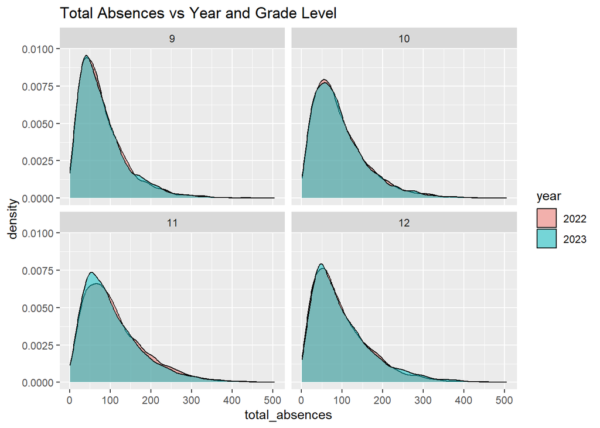

```r
school_data %>%
  ggplot(aes(x = total_absences, fill = year)) +
  geom_density(alpha = .5) +
  facet_wrap(~grade) +
  labs(title = "Total Absences vs Year and Grade Level")
```

These graphs indicated that there wasn’t much difference at all between the distributions of absences from 2022 to 2023 since the red and blue sections overlapped almost perfectly. However, it was a bit difficult to compare the differences between the grade levels on this graph, so another graph had to be made in the Testing Absences vs Grade, School, Period, and Term section.

It is also important to note that the distribution was not perfectly symmetric. The data is right-skewed, meaning that there are a lot of data points clustered on the lower end (a lot of students who don’t miss very much class) and a smaller number of points that extend far outward on the upper extreme (a handful of students who miss a lot of class).

### 2.4.2 Testing Mark vs Grade

The first variable tested against `mark` was `grade`. It was important to see if the two variables depended on each other to see if a certain `grade` level was under performing and needed more attention and assistance to help push for better scores. The chi-square test of independence was used to test the null hypothesis that there was no dependence of `mark` on `grade`.

```r
chisq.test(long_school_data$mark, long_school_data$grade)
```

```
##
##  Pearson's Chi-squared test
##
## data:  long_school_data$mark and long_school_data$grade
## X-squared = 1038.9, df = 12, p-value < 2.2e-16
```

The results of the hypothesis test suggested that there was a dependence of `mark` on `grade`. Certain `grade` levels tended to receive different marks than others. The next step was identifying what those differences are and which grades performed better or worse than others.

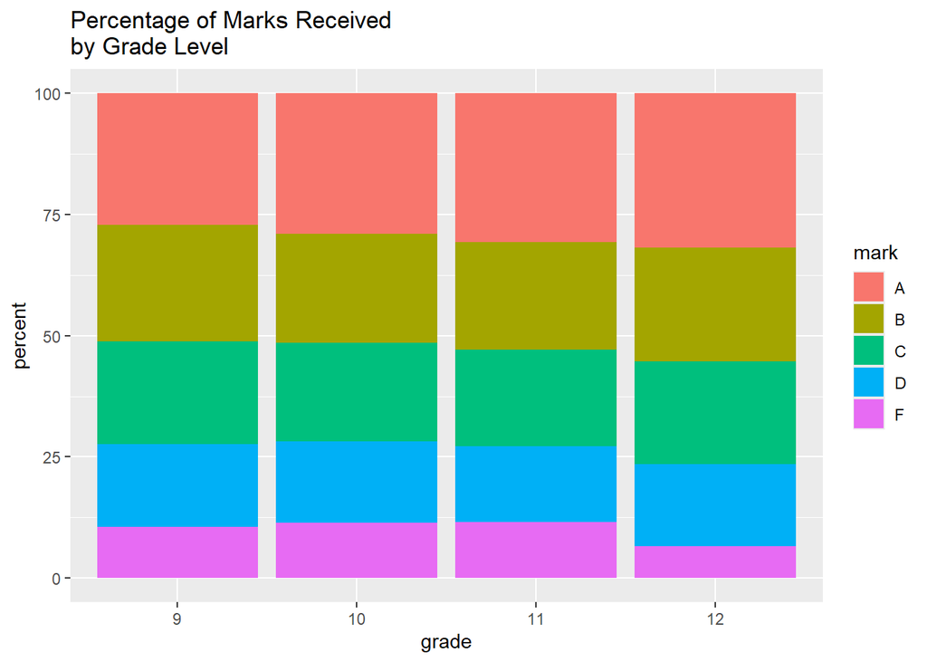

```r
long_data_counts <- long_school_data %>%
  group_by(grade, mark) %>%
  summarize(count = length(student_id))

long_data_count_totals <- long_data_counts %>%
  group_by(grade) %>%
  summarize(sum = sum(count))

long_data_counts <- inner_join(
  long_data_counts,
  long_data_count_totals,
  by = join_by(grade)
)

long_data_counts$percent <- (long_data_counts$count/long_data_counts$sum) * 100

long_data_counts %>%
  ggplot(aes(x = grade, y = percent, fill = mark)) +
  geom_bar(stat = "identity") +
  labs(title = "Percentage of Marks Received
by Grade Level")
```

The plot above shows the differences in mark by grade level. It indicates that the higher a student’s grade level, the more likely they are to receive A’s or B’s for a class. However, 10th graders had the highest failing percentage. It also appears that 12th graders are the least likely to fail a given class, and they receive roughly half the percentage of F’s that the other grades receive. It is also interesting to note that the distribution of `total_absences` doesn’t appear to match the results here. While 11th graders typically had the most absences, they were not the ones that received the most failing grades. They even had the second-highest percentage of A’s and B’s.

### 2.4.3 Testing Mark vs School and Year

To determine which schools need the most help, a chi-square hypothesis test for independence was performed to see if `mark` was dependent on the `school` a student attended. To test the difference between 2022 and 2023, a chi-square hypothesis test was performed on `mark` vs `year` as well.

```r
chisq.test(long_school_data$mark, long_school_data$school_name)
```

```
##
##  Pearson's Chi-squared test
##
## data:  long_school_data$mark and long_school_data$school_name
## X-squared = 1474.4, df = 16, p-value < 2.2e-16
```

```r
chisq.test(long_school_data$mark, long_school_data$year)
```

```
##
##  Pearson's Chi-squared test
##
## data:  long_school_data$mark and long_school_data$year
## X-squared = 358.33, df = 4, p-value < 2.2e-16
```

Both of the tests had stiatistically significant results. The first test indicates that the mark a student receives is dependent on the school they attend. In other words, some schools perform better or worse than others. The second test indicates that the mark a student receive is dependent on the year in which they attend school. Students tend to perform better on some years than others.

To find which schools performed the best or worst and which years had the best or worst performance, two percentage stacked bar plots were produced.

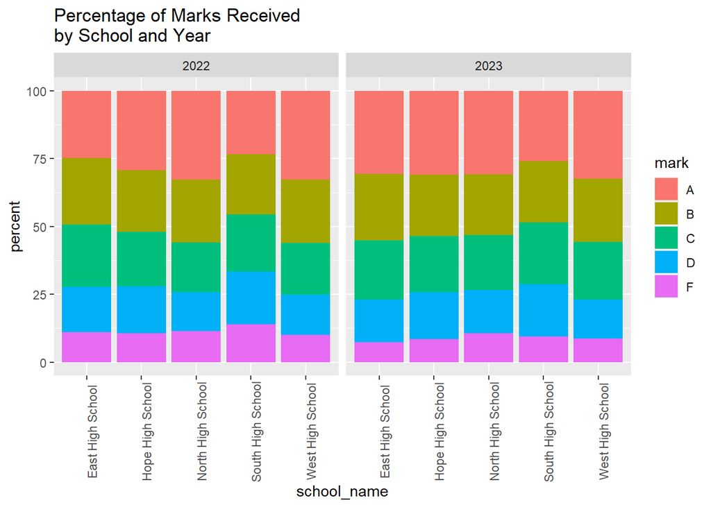

```r
long_data_counts <- long_school_data %>%
  group_by(school_name, year, mark) %>%
  summarize(count = length(student_id))

long_data_count_totals <- long_data_counts %>%
  group_by(school_name, year) %>%
  summarize(sum = sum(count))

long_data_counts <- inner_join(
  long_data_counts,
  long_data_count_totals,
  by = join_by(school_name, year)
)

long_data_counts$percent <- (long_data_counts$count/long_data_counts$sum) * 100

long_data_counts %>%
  arrange(year, school_name, mark) %>%
  ggplot(aes(x = school_name, y = percent, fill = mark)) +
  geom_bar(stat = "identity") +
  facet_wrap(~year) +
  theme(axis.text.x = element_text(angle = 90)) +
  labs(title = "Percentage of Marks Received
by School and Year")
```

To see more clearly which year had the best performance, an additional percentage stacked bar plot was made only of year and mark.

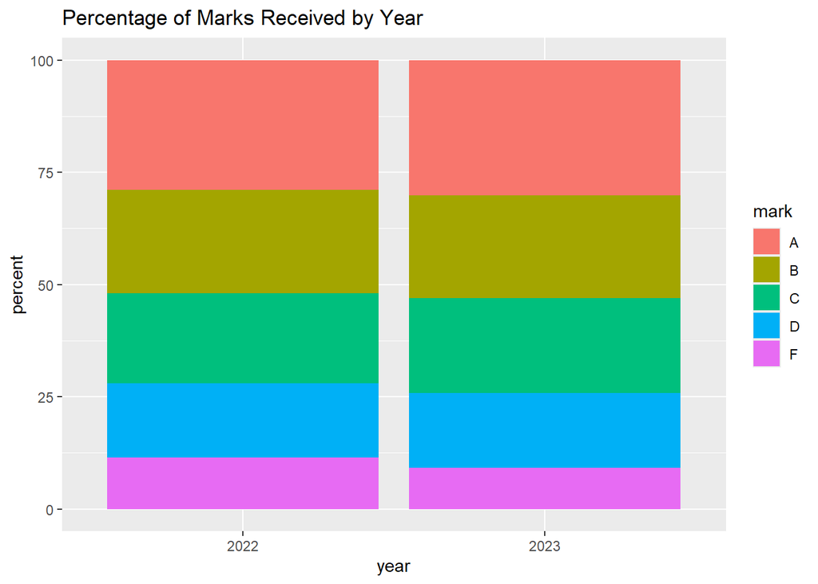

```r
long_data_counts <- long_school_data %>%
  group_by(year, mark) %>%
  summarize(count = length(student_id))

long_data_count_totals <- long_data_counts %>%
  group_by(year) %>%
  summarize(sum = sum(count))

long_data_counts <- inner_join(
  long_data_counts,
  long_data_count_totals,
  by = join_by(year)
)

long_data_counts$percent <- (long_data_counts$count/long_data_counts$sum) * 100

long_data_counts %>%
  arrange(year, mark) %>%
  ggplot(aes(x = year, y = percent, fill = mark)) +
  geom_bar(stat = "identity") +
  labs(title = "Percentage of Marks Received by Year")
```

The results of the plot are comforting. Students performed better in the year 2023, with more A’s, less failing marks overall, and a roughly 20% reduction in F’s. It is worthwhile to find a cause for the improvement in marks or a cause for the lowered marks in 2022 to know what can be done to continue or strengthen this trend.

### 2.4.4 Testing Mark vs Period

It is possible that students are less likely to perform well during certain periods due to their sleep schedules, eating habits, or other reasons. A chi-square test for independence was performed to test the null hypothesis that `period` is independent of `mark`.

```r
chisq.test(long_school_data$period, long_school_data$mark)
```

```
##
##  Pearson's Chi-squared test
##
## data:  long_school_data$period and long_school_data$mark
## X-squared = 483.62, df = 20, p-value < 2.2e-16
```

The results from the hypothesis test indicate that their is a significant difference in the `mark` students typically receive during different periods. To spot these different, a percentage stacked bar plot was made to see which periods generally had better or worse scores.

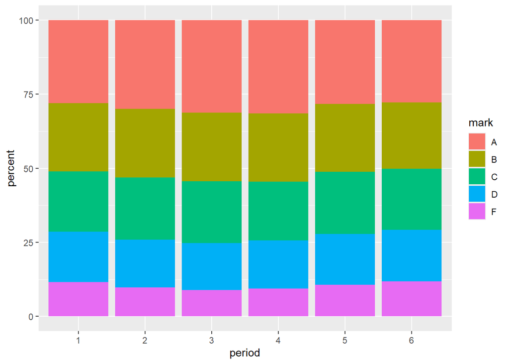

```r
# Calculating the table needed to produce the graph
counts <- long_school_data %>%
  group_by(period, mark) %>%
  summarize(count = length(student_id))

totals <- counts %>%
  group_by(period) %>%
  summarize(total = sum(count))

percentages <- counts %>%
  inner_join(totals, by = join_by(period)) %>%
  mutate(percent = (count / total) * 100)

# Creating and outputting the stacked bar plot
percentages %>%
  arrange(period, mark) %>%
  ggplot(aes(x = period, y = percent, fill = mark)) +
  geom_bar(stat = "identity")
```

The results from the percentage stacked bar plot of mark by period indicated that there was not much difference in the distribution of marks for each period. There was a slight increase in A’s and decrease in F’s in the middle periods 2-4, but the effect was rather small. A heat map was made to help highlight the differences between periods more effectively, and a table was shown to see the exact the differences.

| mark | period1 | period2 | period3 | period4 | period5 | period6 |
| --- | --- | --- | --- | --- | --- | --- |
| A | 28.06272 | 29.891133 | 31.158521 | 31.411285 | 28.30743 | 27.76531 |
| B | 23.02549 | 23.251289 | 23.232480 | 23.054058 | 22.87119 | 22.34693 |
| C | 20.25907 | 20.897759 | 20.850789 | 19.873734 | 21.01449 | 20.65095 |
| D | 17.04426 | 16.140738 | 15.841738 | 16.330396 | 17.08282 | 17.43671 |
| F | 11.60845 | 9.819081 | 8.916473 | 9.330527 | 10.72406 | 11.80010 |

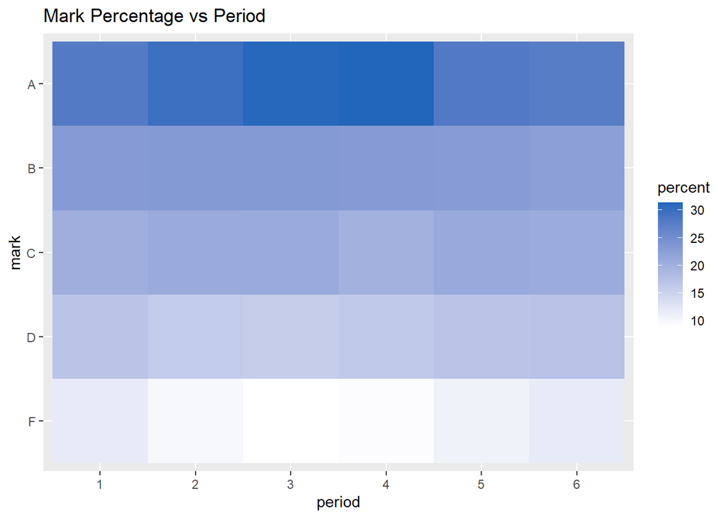

```r
{
  print(knitr::kable(percentages %>%
    pivot_wider(names_from = period,
                values_from = percent,
                id_cols = mark,
                names_glue = "period{period}")))

  print(percentages %>%
    mutate(mark = fct_reorder(mark, 5:1)) %>%
    ggplot(aes(x = period, y = mark, fill = percent)) +
    geom_tile() +
    scale_fill_gradient(low="white", high="#2266BB") +
    labs(title = "Mark Percentage vs Period"))
}
```

### 2.4.5 Testing Mark vs Term

It can also be helpful to see in which term students perform better or worse to adjust accordingly. A chi-square hypothesis test for independence was performed between `term_code` and `mark` to test the null hypothesis that the `mark` a student receives for a class is independent of the `term_code` in which they take their class. The `complete_long_school_data` table was used to perform the calculation to avoid any bias that could be caused by students having a different number of marks.

```r
chisq.test(complete_long_school_data$term_code,
           complete_long_school_data$mark)
```

```
##
##  Pearson's Chi-squared test
##
## data:  complete_long_school_data$term_code and complete_long_school_data$mark
## X-squared = 234.4, df = 4, p-value < 2.2e-16
```

The hypothesis test performed above indicates that there is a significant difference in the grades students receive in the first semester versus the second semester. A graph and a table were then made to help illustrate what the differences were between the two semesters.

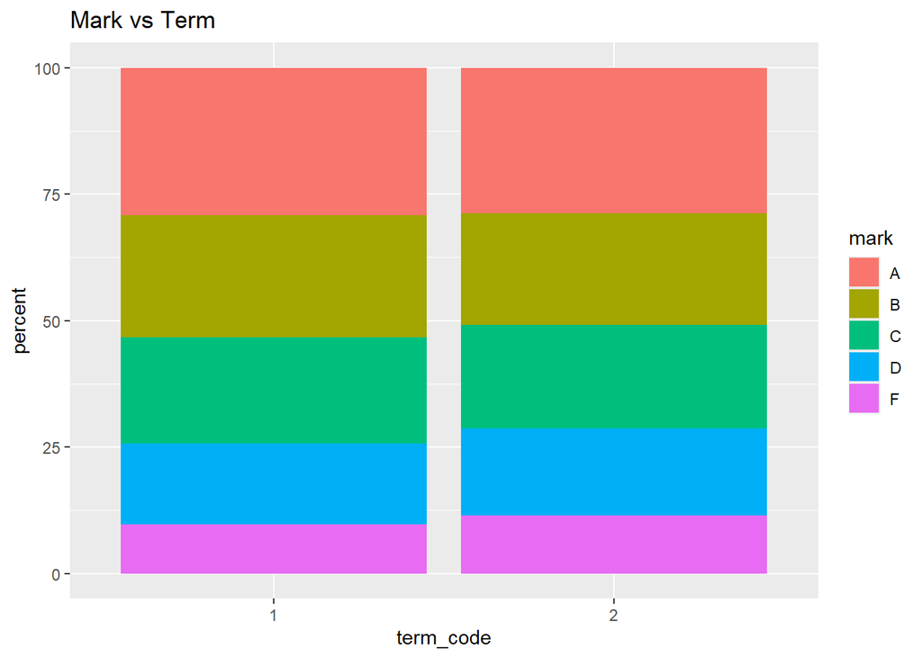

| mark | term1 | term2 | difference |
| --- | --- | --- | --- |
| A | 29.188230 | 28.80947 | -0.3787595 |
| B | 24.070602 | 22.11430 | -1.9562989 |
| C | 21.023026 | 20.34801 | -0.6750169 |
| D | 16.047901 | 17.26418 | 1.2162804 |
| F | 9.670242 | 11.46404 | 1.7937948 |

```r
counts <- complete_long_school_data %>%
  group_by(term_code, mark) %>%
  summarize(count = length(student_id))

totals <- counts %>%
  group_by(term_code) %>%
  summarize(total = sum(count))

percentages <- counts %>%
  inner_join(totals, by = join_by(term_code)) %>%
  mutate(percent = (count / total) * 100)

{
  print(percentages %>%
    ggplot(aes(x = term_code, y = percent, fill = mark)) +
    geom_bar(stat = "identity") +
    labs(title = "Mark vs Term"))

  print(knitr::kable(percentages %>%
    pivot_wider(names_from = term_code,
                values_from = percent,
                id_cols = mark,
                names_glue = "term{term_code}") %>%
    mutate(difference = term2 - term1)))
}
```

The graph and table indicate that there are fewer A’s, B’s and C’s, and more D’s, and F’s in the second semester. The largest difference occurs between the number of B’s and the number of F’s, with roughly 1.96% fewer students receiving B’s and 1.79% more students receiving F’s. This might indicate that students need a bit more help and motivation in the second semester to help perform well. However, while the differences were statistically significant, they weren’t large enough to readily appreciate on the graph and might not be large enough to warrant a response.

### 2.4.6 Testing Mark vs Absences

To get a general sense of the trend between mark and absences, I created boxplots to illustrate the distribution of absences for each possible mark.

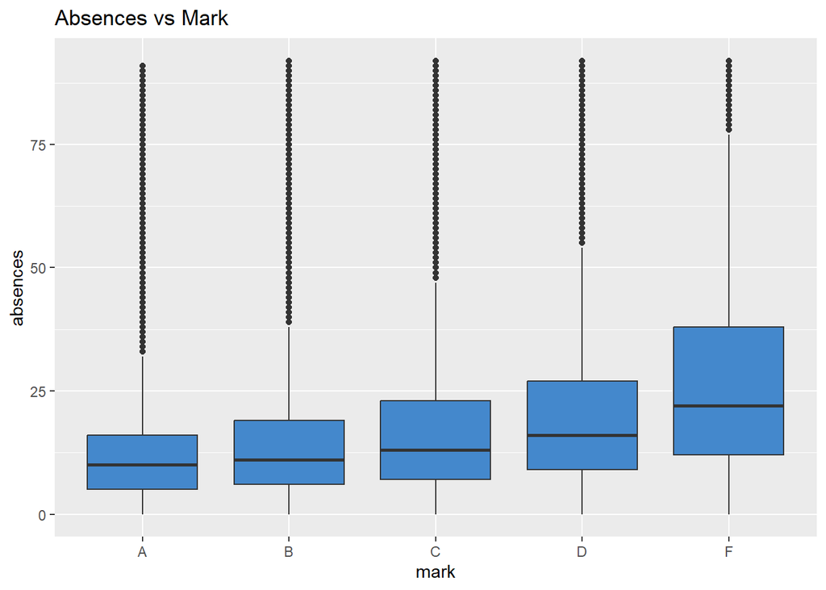

```r
long_school_data %>%
  ggplot(aes(x = mark, y = absences)) +
  geom_boxplot(fill = "#4488CC") +
  labs(title = "Absences vs Mark")
```

The plots of `absences` vs `mark` clearly show an upwards trend, with students that perform poorly in a class being more likely to have more absences in that class. A hypothesis test should be performed to confirm this, however. I decided to use a random forest model to test this hypothesis and to attempt to predict a student’s mark given their number of absences.

First I set split the data into a training group to train the model and a test group to evaluate the model’s accuracy.

```r
set.seed(0)
train_size <- floor(.8 * nrow(long_school_data))
train_indexes <- sample(1:nrow(long_school_data), train_size)
train_data <- long_school_data[train_indexes, ]
test_data  <- long_school_data[-train_indexes, ]
```

Then I fit a full model of the data.

```r
full_formula <- mark ~ absences + school_name + period + term_code + year +
  grade

model = randomForest(formula = full_formula, data = train_data)

# Confusion matrix for the train data
confusionMatrix(predict(model), train_data$mark)
```

```
## Confusion Matrix and Statistics
##
##           Reference
## Prediction     A     B     C     D     F
##          A 44668 31245 25253 17722  8316
##          B  1823  2183  2043  1617   849
##          C  2401  2808  3308  2993  1934
##          D  1919  2473  3333  3844  2538
##          F  1091  1600  2172  2858  4438
##
## Overall Statistics
##
##                Accuracy : 0.3331
##                  95% CI : (0.3309, 0.3353)
##     No Information Rate : 0.2959
##     P-Value [Acc > NIR] : < 2.2e-16
##
##                   Kappa : 0.0965
##
##  Mcnemar's Test P-Value : < 2.2e-16
##
## Statistics by Class:
##
##                      Class: A Class: B Class: C Class: D Class: F
## Sensitivity            0.8606  0.05416  0.09161  0.13240  0.24553
## Specificity            0.3318  0.95314  0.92725  0.92990  0.95093
## Pos Pred Value         0.3512  0.25637  0.24606  0.27249  0.36500
## Neg Pred Value         0.8500  0.77158  0.79751  0.84385  0.91648
## Prevalence             0.2959  0.22977  0.20583  0.16550  0.10303
## Detection Rate         0.2546  0.01244  0.01886  0.02191  0.02530
## Detection Prevalence   0.7251  0.04854  0.07663  0.08041  0.06931
## Balanced Accuracy      0.5962  0.50365  0.50943  0.53115  0.59823
```

```r
# Confusion matrix for the test data
confusionMatrix(predict(model, newdata = test_data), test_data$mark)
```

```
## Confusion Matrix and Statistics
##
##           Reference
## Prediction     A     B     C     D     F
##          A 10974  7936  6351  4490  2032
##          B   467   484   486   364   227
##          C   582   687   790   789   454
##          D   475   623   848   989   678
##          F   292   359   552   769  1160
##
## Overall Statistics
##
##                Accuracy : 0.3283
##                  95% CI : (0.3239, 0.3327)
##     No Information Rate : 0.2916
##     P-Value [Acc > NIR] : < 2.2e-16
##
##                   Kappa : 0.0937
##
##  Mcnemar's Test P-Value : < 2.2e-16
##
## Statistics by Class:
##
##                      Class: A Class: B Class: C Class: D Class: F
## Sensitivity            0.8580  0.04797  0.08752  0.13363  0.25489
## Specificity            0.3302  0.95428  0.92788  0.92802  0.94983
## Pos Pred Value         0.3453  0.23866  0.23925  0.27373  0.37037
## Neg Pred Value         0.8496  0.77038  0.79690  0.84068  0.91674
## Prevalence             0.2916  0.23004  0.20582  0.16875  0.10377
## Detection Rate         0.2502  0.01104  0.01801  0.02255  0.02645
## Detection Prevalence   0.7247  0.04624  0.07529  0.08238  0.07141
## Balanced Accuracy      0.5941  0.50113  0.50770  0.53083  0.60236
```

The results indicate that the full model does a rather poor job at predicting the mark a person will receive based on all of the above factors. It is possible that the model is over fitting the data, but the current model only does slightly better at predicting someone’s mark than simply always guessing what the most common mark is, which is an A. The model had an accuracy of roughly 33% in both the training and the testing data, whereas a mark of “A” had a prevalence of approximately 29%. This means that model has only a 4% increased accuracy over simply assuming that every mark is an A. In fact, the confusion matrix indicates that this model essentially did just that, selected “A” for most of the data points. The detection prevalence for the confusion matrix of both the training data and the testing data indicate that the model predicted that a mark would be an A roughly 72.5% of the time, much more often than it predicted the other values.

Given that the full model was not very accurate and in order to test the hypothesis that `mark` was dependent on `absences`, I then fit a reduced model only testing the predictability of `absences` on `mark`.

```r
formula_reduced <- mark ~ absences
model_reduced <- randomForest(formula_reduced, data = train_data)

confusionMatrix(predict(model_reduced), train_data$mark)
```

```
## Confusion Matrix and Statistics
##
##           Reference
## Prediction     A     B     C     D     F
##          A 45538 32886 27039 19423  9367
##          B     0     0     0     0     0
##          C  3887  4140  4568  4359  3130
##          D  1600  1927  2582  2821  2406
##          F   877  1356  1920  2431  3172
##
## Overall Statistics
##
##                Accuracy : 0.3198
##                  95% CI : (0.3176, 0.322)
##     No Information Rate : 0.2959
##     P-Value [Acc > NIR] : < 2.2e-16
##
##                   Kappa : 0.0728
##
##  Mcnemar's Test P-Value : < 2.2e-16
##
## Statistics by Class:
##
##                      Class: A Class: B Class: C Class: D Class: F
## Sensitivity            0.8774   0.0000  0.12651  0.09716  0.17549
## Specificity            0.2818   1.0000  0.88863  0.94184  0.95816
## Pos Pred Value         0.3392      NaN  0.22744  0.24885  0.32513
## Neg Pred Value         0.8454   0.7702  0.79696  0.84026  0.91005
## Prevalence             0.2959   0.2298  0.20583  0.16550  0.10303
## Detection Rate         0.2596   0.0000  0.02604  0.01608  0.01808
## Detection Prevalence   0.7653   0.0000  0.11449  0.06462  0.05561
## Balanced Accuracy      0.5796   0.5000  0.50757  0.51950  0.56682
```

```r
confusionMatrix(predict(model_reduced, newdata = test_data), test_data$mark)
```

```
## Confusion Matrix and Statistics
##
##           Reference
## Prediction     A     B     C     D     F
##          A 11172  8305  6785  4911  2341
##          B     0     0     0     0     0
##          C  1038  1041  1170  1135   822
##          D   361   453   570   679   560
##          F   219   290   502   676   828
##
## Overall Statistics
##
##                Accuracy : 0.3158
##                  95% CI : (0.3114, 0.3201)
##     No Information Rate : 0.2916
##     P-Value [Acc > NIR] : < 2.2e-16
##
##                   Kappa : 0.0712
##
##  Mcnemar's Test P-Value : < 2.2e-16
##
## Statistics by Class:
##
##                      Class: A Class: B Class: C Class: D Class: F
## Sensitivity            0.8735     0.00  0.12961  0.09174  0.18194
## Specificity            0.2809     1.00  0.88413  0.94668  0.95708
## Pos Pred Value         0.3334      NaN  0.22474  0.25886  0.32922
## Neg Pred Value         0.8436     0.77  0.79672  0.83698  0.90995
## Prevalence             0.2916     0.23  0.20582  0.16875  0.10377
## Detection Rate         0.2547     0.00  0.02668  0.01548  0.01888
## Detection Prevalence   0.7641     0.00  0.11870  0.05981  0.05734
## Balanced Accuracy      0.5772     0.50  0.50687  0.51921  0.56951
```

The results of this model similarly indicate that it does a poor job of predicting the grade a student will receive. The confidence intervals for the accuracy of the model indicate that this model performs worse than the full model. They indicate that the maximum accuracy of the reduced model is around 32%, but the minimum accuracy of the full model is around 32.4%. This model also appears to be a little less sensitive to marks other than A’s. In this model, roughly 76.5% of predictions were “A”, a 4% increase from the full model. These results indicate that `mark` is in fact somewhat dependent on `absences`, but the relationship is not very strong. Regarding which model should be chosen to predict `mark`, the full model is slightly more accurate, but neither model is an accurate predictor.

### 2.4.7 Testing Failing Percentage vs Total Absences

As shown by the random forest models of the data, the number of absences a student has for a class is not an accurate predictor of the mark they receive for the class. This is likely attributable to the fact that some classes require very little effort to receive high scores in, such as physical education or other elective courses. As a result, it is possible and even likely for students to receive A’s in certain classes despite have many absences. If it was known what specific classes students were taking, it would help improve the model’s accuracy and more clearly show a relationship with the number of absences, but this information is not available. However, `total_absences` might be a better predictor for the percentage of classes that students pass or fail because this percentage groups all classes together for each student for all the classes they take, essentially controlling for the fact that some classes are easier than others since each student should have a mix of easy and hard classes.

To start off, a jitter plot with averages marked in red was made of `fail_percent` vs `total_absences` to see if there was any clear relationship.

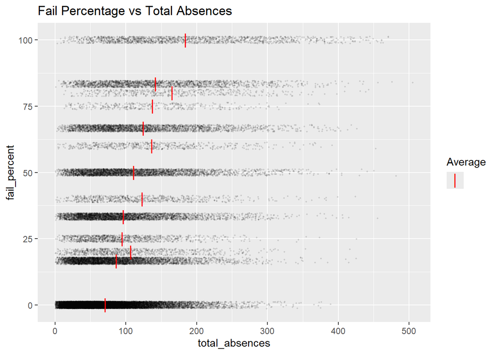

```r
averages <- school_data %>%
  group_by(fail_percent) %>%
  summarize(total_absences = mean(total_absences))

school_data %>%
  ggplot(aes(x = total_absences, y = fail_percent)) +
  geom_jitter(alpha = .1, size = .3) +
  geom_point(data=averages, aes(x = total_absences,
                                y = fail_percent,
                                color = ""),
             size = 5, alpha = 1, shape="|") +
  scale_color_manual(values = "red") +
  labs(color = "Average", title = "Fail Percentage vs Total Absences")
```

The graph clearly showed that `fail_percent` was positively correlated with `total_absences`. The average number of absences tended to increase as the percentage of classes a student failed increased.

Then, to test the relationship for significance, a correlation test was performed using the difference between `total_absences` in the first and second semester and the difference between `fail_percent` in the first and second semester.

First, I calculated the difference in `total_absences` for each student between the first and second semester and the difference in `fail_percent` for each student between the two semesters.

```r
first_semester <- school_data %>%
  dplyr::select(student_id, term_code, total_absences, fail_percent) %>%
  filter(term_code == 1) %>%
  arrange(student_id)

second_semester <- school_data %>%
  dplyr::select(student_id, term_code, total_absences, fail_percent) %>%
  filter(term_code == 2) %>%
  arrange(student_id)

absence_diffs <- second_semester$total_absences - first_semester$total_absences
fail_diffs <- second_semester$fail_percent - first_semester$fail_percent
```

In order to perform a test of correlation, the two variables need to be normally distributed, so the next step I did was testing the variables for normality.

```r
# Testing absence_diffs for normality
print(shapiro.test(sample(absence_diffs, 5000)))
```

```
##
##  Shapiro-Wilk normality test
##
## data:  sample(absence_diffs, 5000)
## W = 0.9551, p-value < 2.2e-16
```

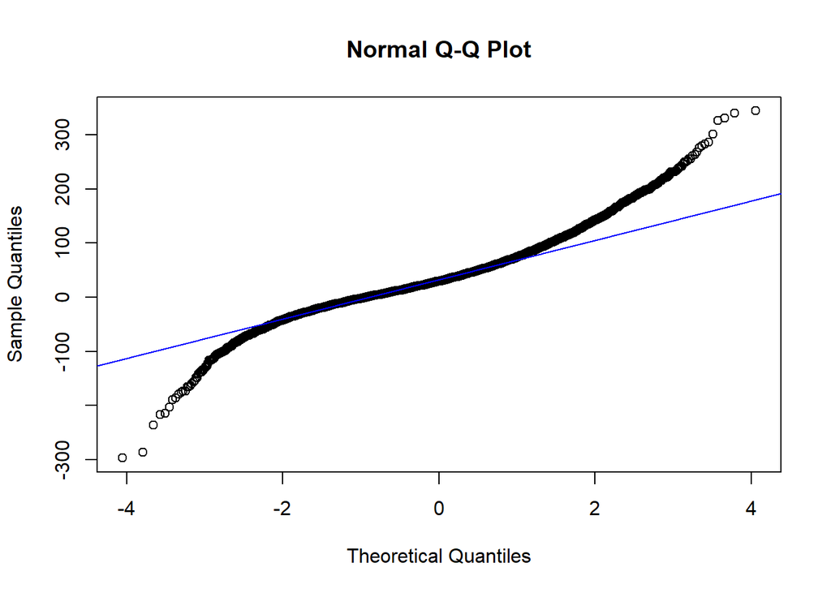

```r
qqnorm(absence_diffs)
qqline(absence_diffs, col = "blue")
```

```r
# Testing fail_diffs for normality
print(shapiro.test(sample(fail_diffs, 5000)))
```

```
##
##  Shapiro-Wilk normality test
##
## data:  sample(fail_diffs, 5000)
## W = 0.89871, p-value < 2.2e-16
```

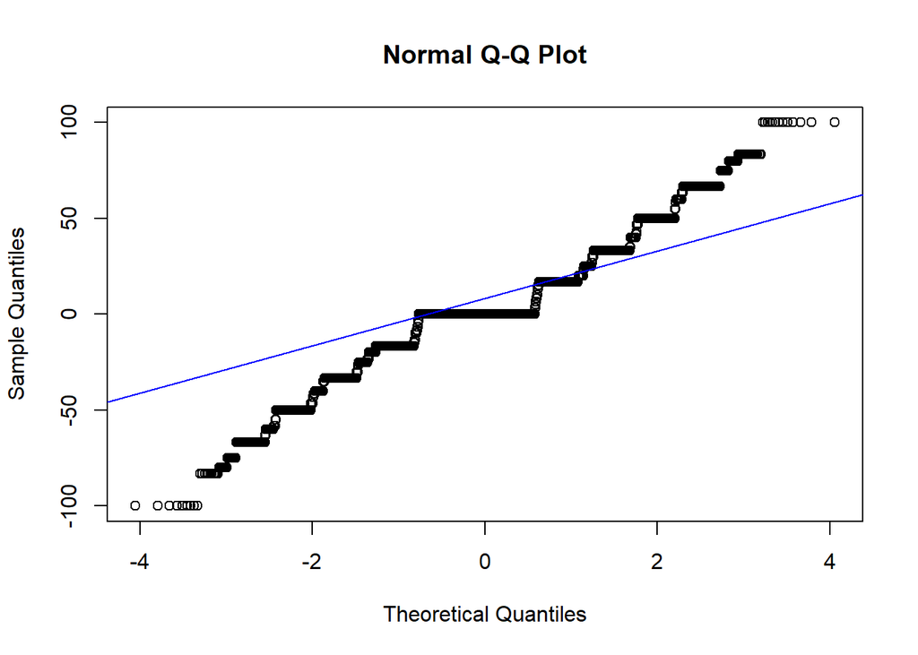

```r
qqnorm(fail_diffs)
qqline(fail_diffs, col = "blue")
```

The tests and normal Q-Q plots for the absence differences and fail percentage differences indicate that neither is normally distributed. Consequently, a nonparametric test was chosen: the Spearman Rank test for correlation.

```r
cor.test(absence_diffs, fail_diffs, method = "spearman")
```

```
##
##  Spearman's rank correlation rho
##
## data:  absence_diffs and fail_diffs
## S = 1.0958e+12, p-value < 2.2e-16
## alternative hypothesis: true rho is not equal to 0
## sample estimates:
##       rho
## 0.1719316
```

The results of the test indicate that there is a significant correlation between the number of absences a student has and the percentage of classes that they fail. As the number of total absences a student has increases from the first semester to the second semester, the percentage of classes that they fail in the second semester tends to increase. However, the relationship is weak, with the estimate for $\rho$ having a value around 0.17. While absences certainly appear to impact performance, they don’t appear to have the potential to be a reliable predictor of performance.

Here is a visualization of the relationship between the difference in `total_absences` between the first and second semester and the difference in `fail_percent` between the first and second semester:

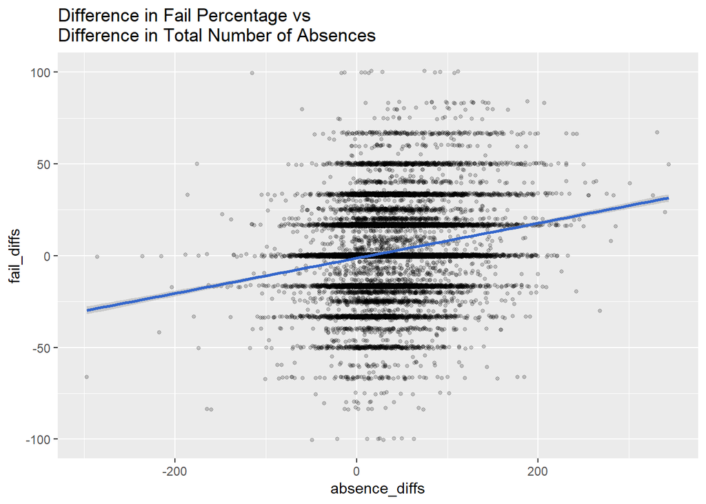

```r
data.frame(absence_diffs = absence_diffs, fail_diffs = fail_diffs) %>%
  ggplot(aes(x = absence_diffs, y = fail_diffs)) +
  geom_jitter(alpha = .2, size = 1) +
  geom_smooth(method="lm", color = "#3366CC") +
  labs(title = "Difference in Fail Percentage vs
Difference in Total Number of Absences")
```

Next, to find an estimate for a critical number of absences, three tables were made for each of the bins for `total_absences`. The first table, `bin_percentage_all_passing`, calculated the percentage of students that passed all of their courses for each of the bins. Note that a student was considered to have passed if they received at least a C for their mark. The second table, `bin_percentage_half_passing`, calculated the percentage of students that passed at least half of their courses for each of the bins. The third table, `bin_percentage_all_failing`, calculated the percentage of students that failed all of their classes.

```r
bin_counts <- school_data %>%
  group_by(total_absences_bin) %>%
  summarize(count = length(student_id))

bin_percentage_all_passing <- school_data %>%
  group_by(total_absences_bin) %>%
  summarize(all_pass_count = sum(fail_percent == 0)) %>%
  inner_join(bin_counts, by = join_by(total_absences_bin)) %>%
  mutate(percentage = 100 * (all_pass_count / count))

bin_percentage_half_passing <- school_data %>%
  group_by(total_absences_bin) %>%
  summarize(half_pass_count = sum(fail_percent <= 50)) %>%
  inner_join(bin_counts, by = join_by(total_absences_bin)) %>%
  mutate(percentage = 100 * (half_pass_count / count))

bin_percentage_all_failing <- school_data %>%
  group_by(total_absences_bin) %>%
  summarize(all_fail_count = sum(fail_percent == 100)) %>%
  inner_join(bin_counts, by = join_by(total_absences_bin)) %>%
  mutate(percentage = 100 * (all_fail_count / count))
```

Here is a graph of the values:

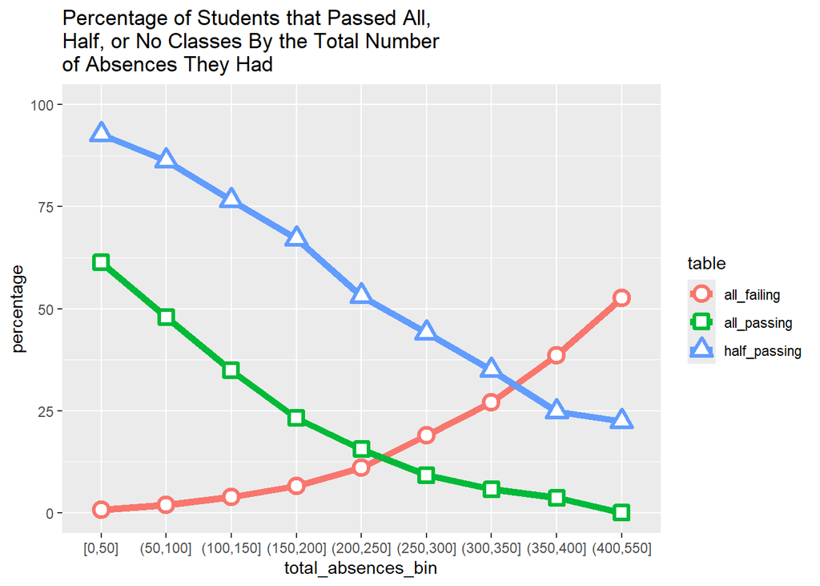

```r
long_bin_percentage = rbind(mutate(bin_percentage_all_passing,
                                   table = "all_passing") %>%
                              dplyr::select(total_absences_bin,
                                            percentage,
                                            table),
                            mutate(bin_percentage_half_passing,
                                   table = "half_passing") %>%
                              dplyr::select(total_absences_bin,
                                            percentage,
                                            table),
                            mutate(bin_percentage_all_failing,
                                   table = "all_failing") %>%
                              dplyr::select(total_absences_bin,
                                            percentage,
                                            table))

long_bin_percentage %>%
  ggplot(aes(y = percentage,
             x = total_absences_bin,
             color = table,
             group = table,
             shape = table)) +
  geom_line(linewidth = 2) +
  geom_point(size=3.5, fill = "white", stroke=1.6) +
  scale_shape_manual(values = c(21, 22, 24)) +
  scale_y_continuous(limits = c(0, 100)) +
  labs(title = "Percentage of Students that Passed All,
Half, or No Classes By the Total Number
of Absences They Had")
```

This graph very clearly shows that there a significant effect of attendance on performance. The `all_passing` table showed an unbreaking trend of decreasing in percentage as the number of total absences increased, indicating that students with more absences were less likely to pass all there courses. Similarly, the `half_passing` table showed an unbreaking trend of decreasing in percentage as the number of total absences increased, providing evidence that students are more likely to pass at least half of their classes if they have a lower number of absences. Lastly, the `all_failing` table showed an unbreaking increasing trend as the number of total absences increased, suggesting that students with more absences are more likely to fail all of their courses.

Finally, confidence intervals were calculated for the `all_passing_percent`, `half_passing_percent`, and `all_failing_percent` for each of the attendance bins to find which differences were significant and to provide a critical point at which teachers should start being concerned for a student. The Bonferroni correction was used to adjust the confidence levels and critical p-value since there were multiple confidence intervals for each table.

```r
# Adjusting alpha using Bonferroni Correction
alpha = .05
n = nrow(bin_percentage_half_passing)
alpha_adj = alpha / n
conf = 1 - alpha_adj

# Initializing the confidence interval columns
bin_percentage_all_passing$CI_lower = numeric(n)
bin_percentage_half_passing$CI_lower = numeric(n)
bin_percentage_all_failing$CI_lower = numeric(n)
bin_percentage_all_passing$CI_upper = numeric(n)
bin_percentage_half_passing$CI_upper = numeric(n)
bin_percentage_all_failing$CI_upper = numeric(n)

# Calculating the confidence intervals for each table
for (i in 1:nrow(bin_percentage_all_passing)) {
  x = bin_percentage_all_passing$all_pass_count[i]
  n = bin_percentage_all_passing$count[i]
  CI = binom.test(x, n, x/n, conf.level = conf)$conf.int
  bin_percentage_all_passing$CI_lower[i] = CI[1] * 100
  bin_percentage_all_passing$CI_upper[i] = CI[2] * 100
}

for (i in 1:nrow(bin_percentage_half_passing)) {
  x = bin_percentage_half_passing$half_pass_count[i]
  n = bin_percentage_half_passing$count[i]
  CI = binom.test(x, n, x/n, conf.level = conf)$conf.int
  bin_percentage_half_passing$CI_lower[i] = CI[1] * 100
  bin_percentage_half_passing$CI_upper[i] = CI[2] * 100
}

for (i in 1:nrow(bin_percentage_all_failing)) {
  x = bin_percentage_all_failing$all_fail_count[i]
  n = bin_percentage_all_failing$count[i]
  CI = binom.test(x, n, x/n, conf.level = conf)$conf.int
  bin_percentage_all_failing$CI_lower[i] = CI[1] * 100
  bin_percentage_all_failing$CI_upper[i] = CI[2] * 100
}
```

Confidence Intervals of All Passing Percentage by Total Absences Bin

| total_absences_bin | CI_lower | CI_upper |
| --- | --- | --- |
| [0,50] | 60.1014509 | 62.615091 |
| (50,100] | 46.7588410 | 49.136226 |
| (100,150] | 33.3668997 | 36.430085 |
| (150,200] | 21.3501329 | 25.202980 |
| (200,250] | 13.2933549 | 18.014210 |
| (250,300] | 6.6921985 | 12.245388 |
| (300,350] | 3.0879012 | 9.721400 |
| (350,400] | 0.8542096 | 9.949872 |
| (400,550] | 0.0000000 | 7.452553 |

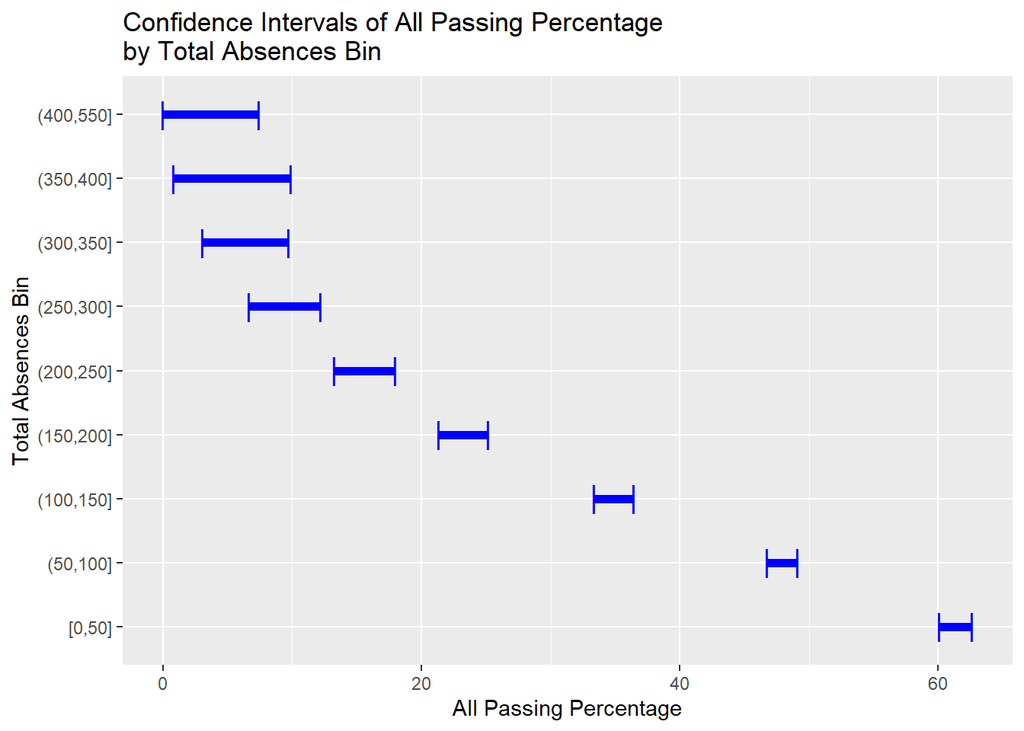

```r
{
  print(knitr::kable(dplyr::select(bin_percentage_all_passing,
                      total_absences_bin,
                      CI_lower,
                      CI_upper),
               caption = "Confidence Intervals of All Passing Percentage
by Total Absences Bin"))

  bin_percentage_all_passing <- bin_percentage_all_passing %>%
    pivot_longer(cols = starts_with("CI"))

  bin_percentage_all_passing %>%
    ggplot(aes(x = value, y = total_absences_bin)) +
    geom_point(shape = "|", color = "blue", size = 5) +
    geom_line(linewidth = 2, color = "blue") +
    labs(x = "All Passing Percentage",
         y = "Total Absences Bin",
         title = "Confidence Intervals of All Passing Percentage
by Total Absences Bin")
}
```

Confidence Intervals of Half Passing Percentage by Total Absences Bin

| total_absences_bin | CI_lower | CI_upper |
| --- | --- | --- |
| [0,50] | 91.96997 | 93.32015 |
| (50,100] | 85.44022 | 87.08020 |
| (100,150] | 75.18716 | 77.91102 |
| (150,200] | 64.95446 | 69.23666 |
| (200,250] | 49.88388 | 56.36097 |
| (250,300] | 39.39570 | 48.82710 |
| (300,350] | 28.63726 | 41.81354 |
| (350,400] | 16.08213 | 35.35922 |
| (400,550] | 10.83043 | 37.98459 |

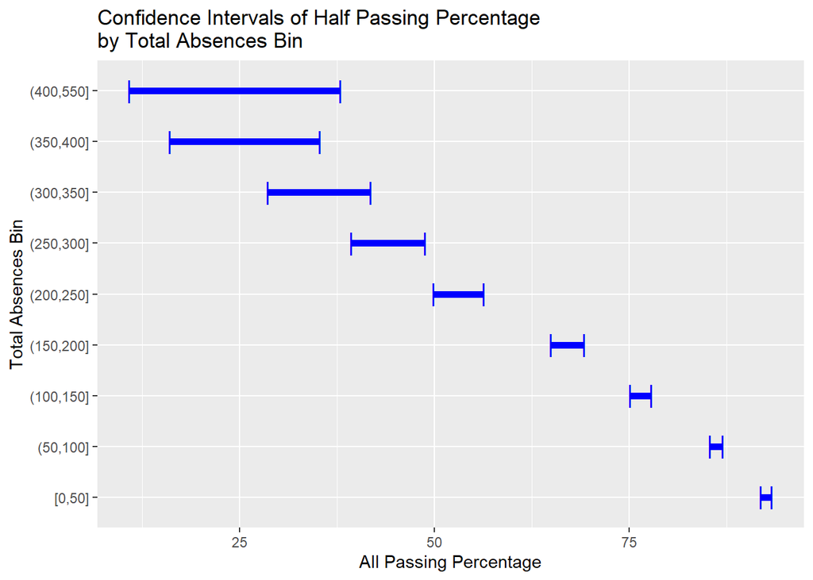

```r
{
  print(knitr::kable(dplyr::select(bin_percentage_half_passing,
                      total_absences_bin,
                      CI_lower,
                      CI_upper),
               caption = "Confidence Intervals of Half Passing Percentage
by Total Absences Bin"))

  bin_percentage_half_passing <- bin_percentage_half_passing %>%
  pivot_longer(cols = starts_with("CI"))

  bin_percentage_half_passing %>%
    ggplot(aes(x = value, y = total_absences_bin)) +
    geom_point(shape = "|", color = "blue", size = 5) +
    geom_line(linewidth = 2, color = "blue") +
    labs(x = "All Passing Percentage",
         y = "Total Absences Bin",
         title = "Confidence Intervals of Half Passing Percentage
by Total Absences Bin")
}
```

Confidence Intervals of All Failing Percentage by Total Absences Bin

| total_absences_bin | CI_lower | CI_upper |
| --- | --- | --- |
| [0,50] | 0.5606545 | 1.019179 |
| (50,100] | 1.5879476 | 2.242907 |
| (100,150] | 3.3471399 | 4.606785 |
| (150,200] | 5.4983333 | 7.771330 |
| (200,250] | 9.1378395 | 13.233794 |
| (250,300] | 15.4456900 | 22.925804 |
| (300,350] | 21.2161887 | 33.507862 |
| (350,400] | 28.1111723 | 49.704371 |
| (400,550] | 36.3876636 | 68.490258 |

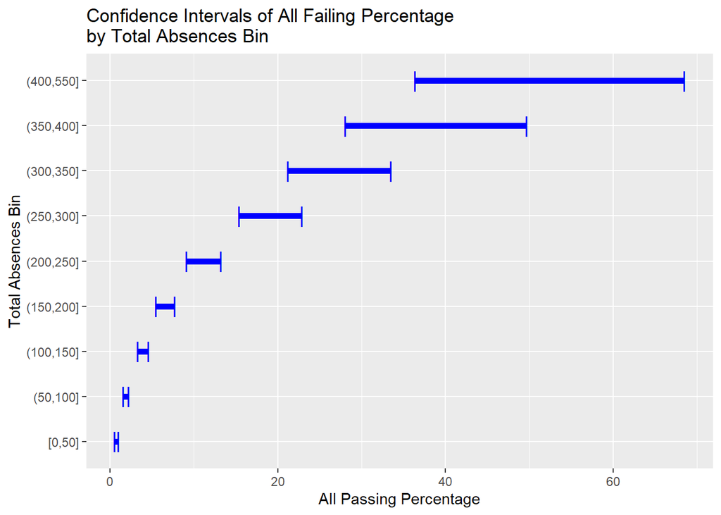

```r
{
  print(knitr::kable(dplyr::select(bin_percentage_all_failing,
                      total_absences_bin,
                      CI_lower,
                      CI_upper),
               caption = "Confidence Intervals of All Failing Percentage
by Total Absences Bin"))

  bin_percentage_all_failing <- bin_percentage_all_failing %>%
  pivot_longer(cols = starts_with("CI"))

  bin_percentage_all_failing %>%
    ggplot(aes(x = value, y = total_absences_bin)) +
    geom_point(shape = "|", color = "blue", size = 5) +
    geom_line(linewidth = 2, color = "blue") +
    labs(x = "All Passing Percentage",
         y = "Total Absences Bin",
         title = "Confidence Intervals of All Failing Percentage
by Total Absences Bin")
}
```

### 2.4.8 Testing Absences vs Term, Grade, Period, and School

At this point, all of the analysis of `mark` and `fail_percent` was complete. As a final step, I analyzed the effects of all available variables on the number of absences a student has. I didn’t create any models, but I tested if any of the provided variables had any significant relationship with a student’s attendance. The results of this analysis could help reduce absences and potentially boost student performance. The variables `term_code`, `grade`, `period`, and `school_name` were all tested against `absences`.

Firstly, I created a density plot to see the relationship between term and total_absences.

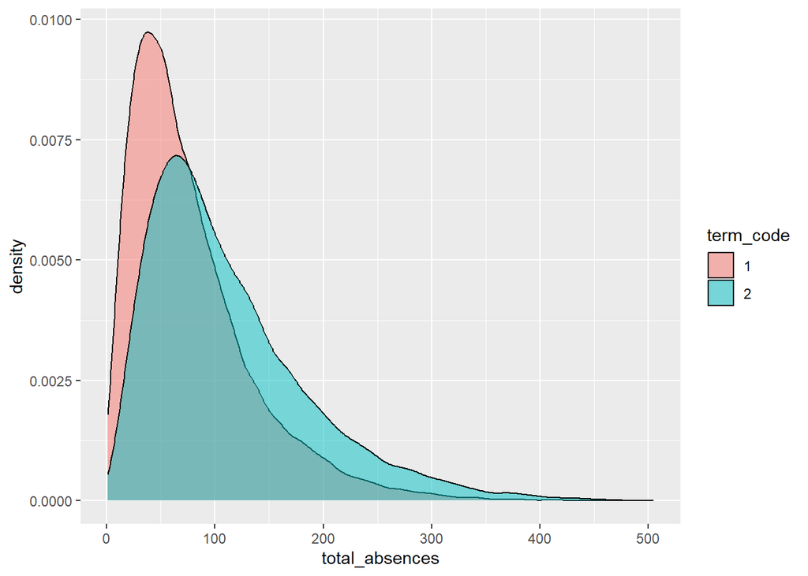

```r
school_data %>%
  ggplot(aes(x = total_absences, fill = term_code)) +
  geom_density(alpha = .5)
```

The density plot of `total_absences` vs `term_code` appeared to indicate that there was a significant difference in the distribution of `total_absences` in each term. In the first term, students typically had fewer total absences, and students tended to have many more absences in the second term.

To test the significance of the dependence of `term_code` on `total_absences`, it would be ideal to use a pairwise T-test on `total_absences` for the first and second semester. However, it was found in the section Testing Failing Percentage vs Total Absences that `absence_diffs` is not normally distributed. Given the very large sample size, this likely doesn’t matter, but the Wilcoxon signed rank test, a nonparametric alternative to the pairwise T-test, was performed as well to help confirm the results.

```r
# As a reminder, absence_diffs is the difference between
# total_absences from the first semester to the second
# semester. (second_semester - first_semester)
t.test(absence_diffs)
```

```
##
##  One Sample t-test
##
## data:  absence_diffs
## t = 111.44, df = 19949, p-value < 2.2e-16
## alternative hypothesis: true mean is not equal to 0
## 95 percent confidence interval:
##  34.47615 35.71062
## sample estimates:
## mean of x
##  35.09338
```

```r
wilcox.test(absence_diffs)
```

```
##
##  Wilcoxon signed rank test with continuity correction
##
## data:  absence_diffs
## V = 175837716, p-value < 2.2e-16
## alternative hypothesis: true location is not equal to 0
```

Both tests had signficant results, indicating that the number of absences between the two semesters is different. An additional table was made to spot the exact differences between the semesters

```r
semester_summary <- school_data %>%
  group_by(term_code) %>%
  summarize(mean_total_absences = mean(total_absences),
            median_total_absences = median(total_absences))

mean_absences3 <-
  (semester_summary$mean_total_absences[2] -
  semester_summary$mean_total_absences[1]) /
  semester_summary$mean_total_absences[1] * 100

median_absences3 <-
  (semester_summary$median_total_absences[2] -
  semester_summary$median_total_absences[1]) /
  semester_summary$median_total_absences[1] * 100

percentage_data <- data.frame(term_code = "percentage_change",
                              mean_total_absences = mean_absences3,
                              median_total_absences = median_absences3)

semester_summary <- rbind(semester_summary, percentage_data)

semester_summary
```

| term_code | mean_total_absences | median_total_absences |
| --- | --- | --- |
| 1 | 77.90967 | 63.00000 |
| 2 | 113.00306 | 95.00000 |
| percentage_change | 45.04368 | 50.79365 |

The tables indicate that there are roughly 45% more absences in the second semester per student. The difference in the median is even more extreme, with a more than 50% increase in absences in the second semester.

Secondly, it was important to test if there was a significant difference in the number of absences for each grade. the Kruskal-Wallis test was performed to test if there was a difference in the average number of absences for each grade. This test was chosen over the ANOVA test because the data has been found to not be normally distributed.

```r
kruskal.test(total_absences ~ grade, school_data)
```

```
##
##  Kruskal-Wallis rank sum test
##
## data:  total_absences by grade
## Kruskal-Wallis chi-squared = 795.35, df = 3, p-value < 2.2e-16
```

The results of the test are statistically significant, indicating that there is a difference in the average number of `total_absences` for at least 1 `grade`. Boxplots were plotted to spot any differences.

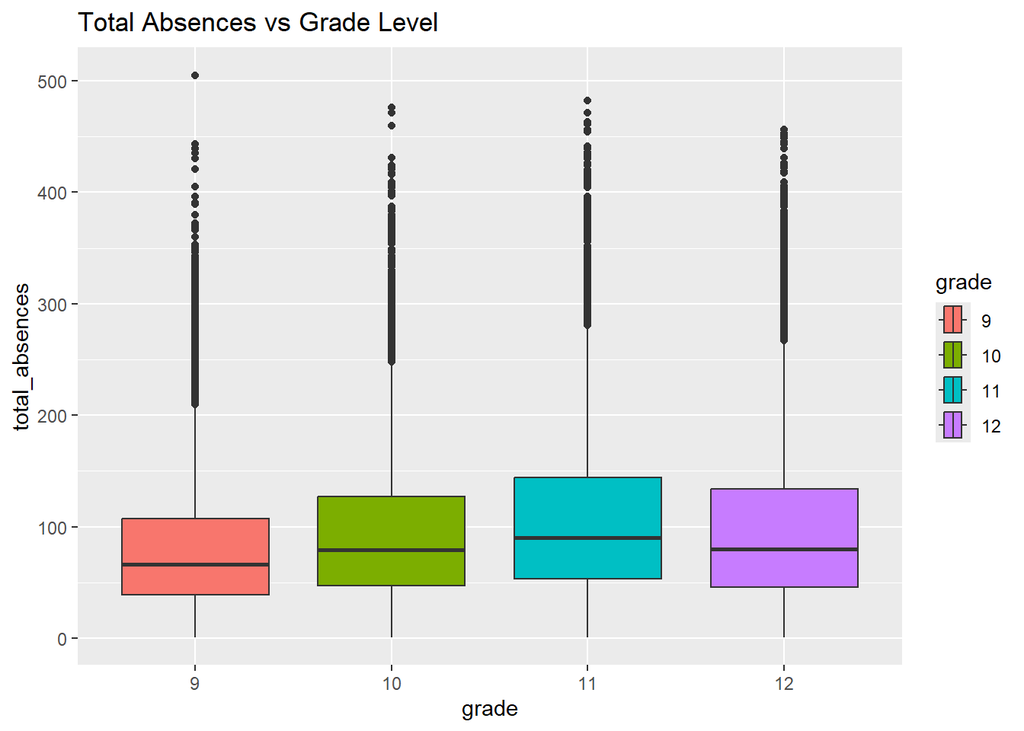

```r
school_data %>%
  ggplot(aes(x = total_absences, y = grade, fill = grade)) +
  geom_boxplot() +
  coord_flip() +
  labs(title= "Total Absences vs Grade Level")
```

The boxplots show that 9th graders had the lowest median number of `total_absences` and the lowest variability as well. 11th graders, on the other hand, had the highest median number of `total_absences` and the highest variability.

The dependence of `period` on `absences` was then tested. For this test, the `long_school_data_with_NAs` was used because it was in the necessary long data format, and, since there was no missing information for any of the periods and absence columns, there was no need to remove the rows with NAs. To test the dependence of `absences` on `period`, the Kruskal-Wallis test was performed to test if there was a difference in the average number of absences for each period. Since the data is not normally distributed, the ANOVA test would not have been appropriate here.

```r
kruskal.test(absences ~ period, long_school_data_with_NAs)
```

```
##
##  Kruskal-Wallis rank sum test
##
## data:  absences by period
## Kruskal-Wallis chi-squared = 7372.5, df = 5, p-value < 2.2e-16
```

The very low p-value of the test indicates tat there is a signficant different in the number of absences for each period. A graph of boxplots was made to identify these differences, and a table was outputted to identify the exact numerical differences.

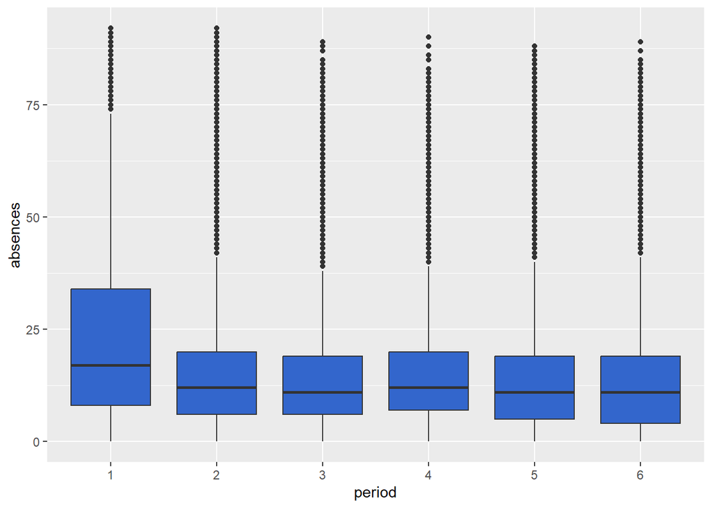

```r
long_school_data_with_NAs %>%
  ggplot(aes(x = period, y = absences)) +
  geom_boxplot(fill = "#3366CC")
```

```r
long_school_data_with_NAs %>%
  group_by(period) %>%
  summarize(mean_absences = mean(absences),
            median_absences = median(absences))
```

| period | mean_absences | median_absences |
| --- | --- | --- |
| 1 | 23.64699 | 17 |
| 2 | 15.49100 | 12 |
| 3 | 14.35419 | 11 |
| 4 | 14.79554 | 12 |
| 5 | 13.56521 | 11 |
| 6 | 13.60343 | 11 |

The boxplots indicate that first period had a substantially larger number of absences. The table confirms this and indicates that there are more than 50% more absences in the first period than any other period. The table also indicates that the number of absences tends to decrease for later periods, but there is an unexpected increase in absences in the 4th period. It is expected for there to be a larger number of absences in the first period since late students might skip the period entirely or might not be counted as present when they show up late for their first class. However, there should be some investigation into why there is a small increase in absences for 4th period. It is possible that students tend to skip this period, or there might be some other explanation. Surprisingly, however, it is one of the periods in which students tend to perform somewhat better.

Finally, the relationship between `school_name` and `total_absences` was explored. To help the school district to identify where to focus its attention and to help it spot risk factors for absences, it would be important to know which schools have the most or worst offenders for absences. To test if any schools had a different average number of `total_absences` than the other schools, the Kruskal-Wallis test was performed since the data is not normally distributed.

```r
kruskal.test(total_absences ~ school_name, school_data)
```

```
##
##  Kruskal-Wallis rank sum test
##
## data:  total_absences by school_name
## Kruskal-Wallis chi-squared = 1100.1, df = 4, p-value < 2.2e-16
```

The test had a significant result, indicating that different school tend to have a different average number of absences. Similar to the previous steps, a series of boxplots was plotted to identify these differences.

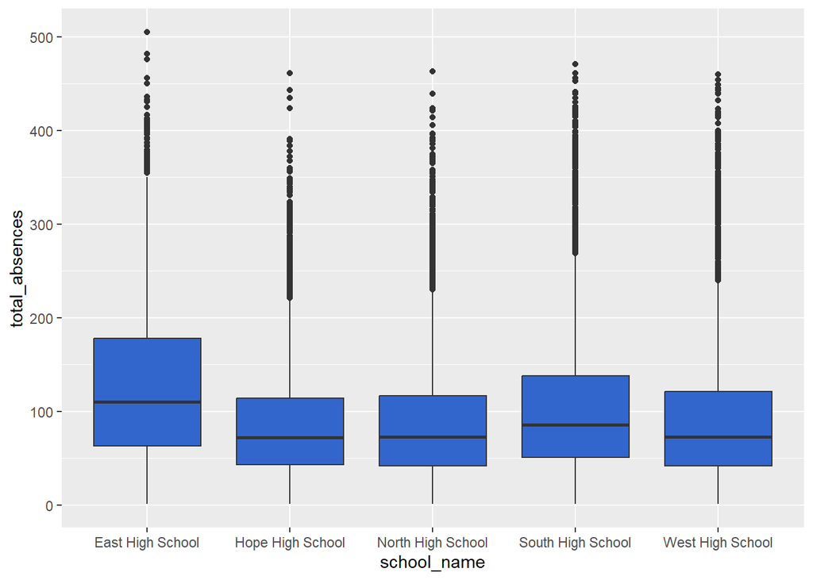

```r
school_data %>%
  ggplot(aes(x = school_name, y = total_absences)) +
  geom_boxplot(fill = "#3366CC")
```

The boxplots indicate that East High School tends to have the most absences, and South High School has a bit more than the other schools. Hope High School, North High School, and West High School appear to have a comparable number of absences.

### 2.4.9 Summary of Findings from Analysis

1. The distribution of the number of absences students have is right-skewed
2. Mark is dependent on grade
   - 10th graders have the highest percentage of failing marks, but 9th graders have the lowest percentage of A’s.
3. Mark is dependent on school
   - South High School performs that worst, with the least percentage of A’s and the highest percentage of failing marks in both 2022 and 2023
4. Mark is dependent on year
   - Students performed better in 2023
5. The effect of school on mark is dependent on the year
6. Mark is dependent on period
   - Students perform best during periods 3 and 4
   - Students perform the worst during period 6
7. Mark is dependent on term
   - Students tend to have worse marks in the second semester
8. Mark is dependent on absences
   - Students tend to have have worse marks the more absences they have
9. The percentage of classes a student fails is weakly positively correlated with the number of absences a student has
10. As little as 50 total absences (roughly 10 days of school) can have a significant impact on the percentage of classes that a student passes or fails.
11. The number of absences a student has is dependent on the semester, grade level, period, and school in which they take the class.
    - Roughly 45% increase in absences in the second semester
    - 9th graders have the least absences; 11th graders have the most
    - 1st period has a full 50% more absences than any other period
    - Absences tend to decrease in later periods, but there is a small increase in absences in 4th period
    - East High School has the most absences, with South High School having the second most

## 2.5 Linear Model Fail_Percent vs Total_Absences

As a final step for quantifying the relationship between attendance and performance, I created a linear model for `fail_percent` vs `total_absences`. Firstly, the data was split into a test group and a train group. Then a linear model was fit for all of the relevant variables, including `fail_percent`, `total_absences`, `school_name`, `term_code`, and `year`. The model was evaluated, and then transformations were performed to improve the model. The new model was then reevaluated, and the best model was chosen.

### 2.5.1 Creating Dummy Variables for School_Name

Linear models require that all variables be numerical. In order to achieve this with character variables like `school_name`, dummy variables must be created.. In this step, I created columns for the “dummy variables.”

```r
school_data <- dummy_cols(school_data,
                          "school_name",
                          remove_first_dummy = TRUE,
                          omit_colname_prefix = TRUE)
```

### 2.5.2 Splitting the Data

To validate the linear model, the data was first split into a training group to fit the model and a testing group to evaluate the model’s prediction ability. The variable `train_indexes` stores the row indexes for the training data, and the variable `test_indexes` stores the row indexes for the testing data.

```r
train_size <- floor(nrow(school_data) * .8)
test_size <- nrow(school_data) - train_size
set.seed(100)
train_indexes <- sample(1:nrow(school_data), train_size)
test_indexes <- (1:nrow(school_data))[-train_indexes]
```

### 2.5.3 Fitting the Initial Model

Once the data was split and prepared for the model, a full linear model of all relevant variables was fit.

```r
model = lm(fail_percent ~ total_absences * term_code + year
           + `Hope High School` + `North High School`
           + `South High School` + `West High School`,
           data = school_data[train_indexes, ])

summary(model)
```

```
##
## Call:
## lm(formula = fail_percent ~ total_absences * term_code + year +
##     `Hope High School` + `North High School` + `South High School` +
##     `West High School`, data = school_data[train_indexes, ])
##
## Residuals:
##     Min      1Q  Median      3Q     Max
## -96.210 -19.773  -8.836  18.040  91.315
##
## Coefficients:
##                            Estimate Std. Error t value Pr(>|t|)
## (Intercept)                1.834199   0.644131   2.848  0.00441 **
## total_absences             0.220593   0.003804  57.983  < 2e-16 ***
## term_code2                -1.286310   0.535599  -2.402  0.01633 *
## year2023                  -2.366138   0.306386  -7.723 1.17e-14 ***
## `Hope High School`         9.695764   0.592569  16.362  < 2e-16 ***
## `North High School`        8.564819   0.602170  14.223  < 2e-16 ***
## `South High School`        9.991837   0.594248  16.814  < 2e-16 ***
## `West High School`         5.433821   0.596051   9.116  < 2e-16 ***
## total_absences:term_code2 -0.039545   0.004759  -8.309  < 2e-16 ***
## ---
## Signif. codes:  0 '***' 0.001 '**' 0.01 '*' 0.05 '.' 0.1 ' ' 1
##
## Residual standard error: 27.36 on 31911 degrees of freedom
## Multiple R-squared:  0.1886, Adjusted R-squared:  0.1884
## F-statistic: 927.3 on 8 and 31911 DF,  p-value: < 2.2e-16
```

### 2.5.4 Evaluating the Model

From the results shown, all of the regressors appear to be significant, and the one regressor that was most significant, as indicated by its large T value, was `total_absences`. However, the model performs rather poorly. The model explains less than 20% of the variance in `fail_percent`, as indicated by the R<sup>2</sup> value. This suggests that the model is a very poor predictor and that there are extraneous variables that affect `fail_percent` much more substantially.

I then tested the model on the testing data set to see how well it was able to predict the values.

```r
predictions <- predict(model, newdata = school_data[test_indexes, ])
SST <- sum((school_data$fail_percent[test_indexes]
           - mean(school_data$fail_percent[test_indexes]))^2)
SSRes <- sum((school_data$fail_percent[test_indexes] - predictions)^2)

R2Pred <- (SST - SSRes) / SST

cat("R-square prediction:", R2Pred)
```

```
## R-square prediction: 0.1963018
```

The prection R<sup>2</sup> value is similar to the R<sup>2</sup> value of the model, but both values indicate that the model performs poorly. However, the model still performs better than simply using the average value of `fail_percent` as the estimate.

One significant problem with the model is that the residuals are not normally distributed. Here is a plot of the residuals:

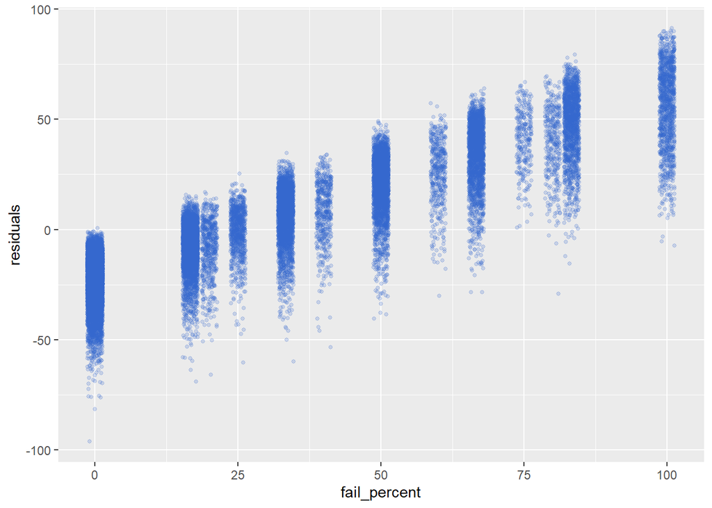

```r
data.frame(residuals = residuals(model),
           fail_percent = school_data[train_indexes, "fail_percent"]) %>%
  ggplot(aes(x = fail_percent, y = residuals)) +
  geom_jitter(color = "#3366CC", alpha = .2, size = 1)
```

The plot of the residuals indicates that they are not uniformly distributed. The residuals tend to be negative for lower fail_percentages, and they tend to be positive for higher fail_percentages. They also don’t appear to be normally distributed, but a normal Q-Q plot and Shapiro-Wilk test for normality helped confirm that they are not normally distributed.

```r
shapiro.test(sample(residuals(model), 5000))
```

```
##
##  Shapiro-Wilk normality test
##
## data:  sample(residuals(model), 5000)
## W = 0.94396, p-value < 2.2e-16
```

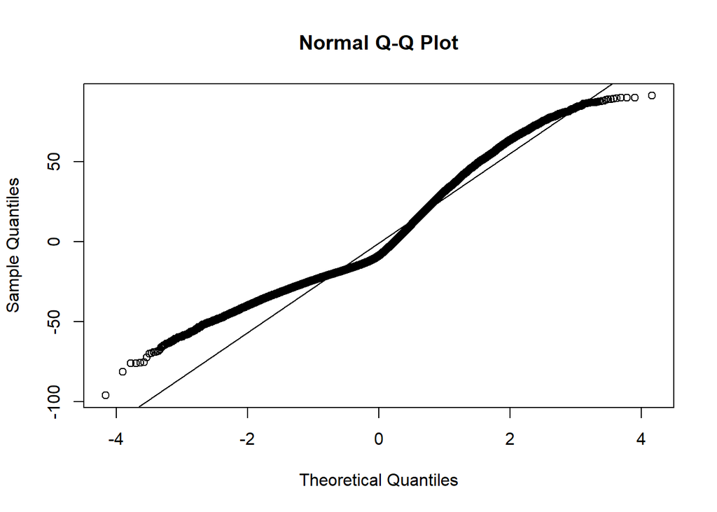

```r
qqnorm(residuals(model))
qqline(residuals(model))
```

### 2.5.5 Performing Transformations

In an attempt to make the residuals more normally distributed, data transformations were performed on the data. First, the data was prepped and tested for the Box-Cox tranformation on the response variable `fail_percent`.

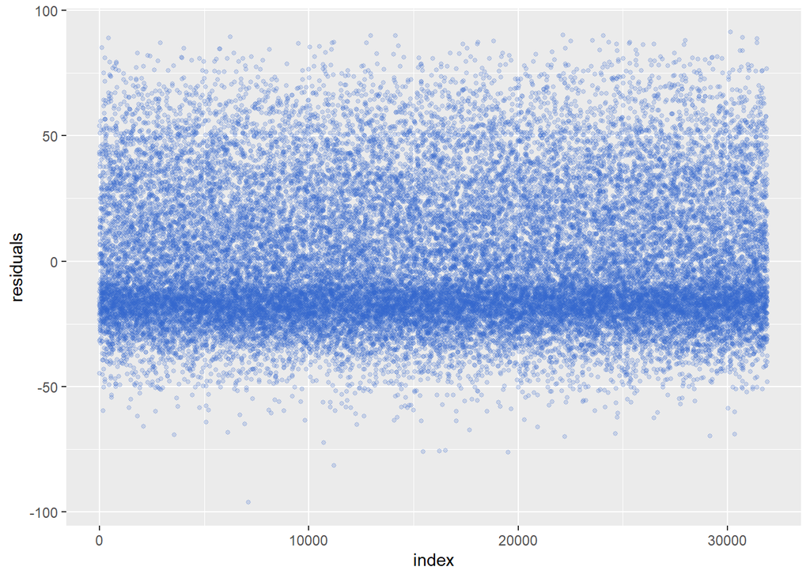

```r
# Showing the residuals from the original model
data.frame(residuals = residuals(model), index = 1:length(train_indexes)) %>%
  ggplot(aes(x = index, y = residuals)) +
  geom_point(color = "#3366CC", alpha = .2, size = 1)
```

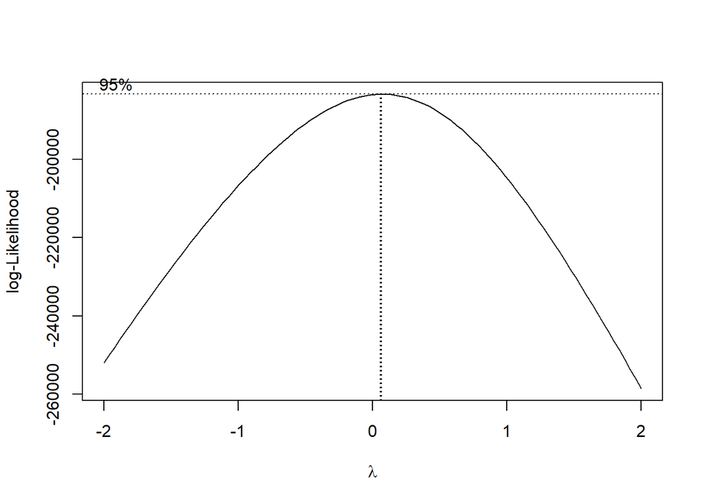

```r
# Calculating new columns needed to test for transformations
school_data <- school_data %>%
  mutate(fail_percent_adj = fail_percent + 1,
         total_absences_adj = total_absences + 1,
         term_code_adj = as.integer(term_code),
         year_adj = as.integer(as.character(year)))

model = lm(fail_percent_adj ~ total_absences_adj * term_code_adj + year_adj
           + `Hope High School` + `North High School`
           + `South High School` + `West High School`,
           data = school_data[train_indexes, ])

# Using the Box-Cox method to test for transformation of the response variable
MASS::boxcox(model)
```

```r
# Applying log transformation to fail_percent_adj
school_data$fail_percent_trans <- log(school_data$fail_percent_adj)
```

The test for the Box-Cox transformation indicated that a log transform would be appropriate, so `fail_percent_adj` was transformed using the natural log function and stored in the column `fail_percent_trans`.

Next, the regressors were tested using the Box-Tidwell method for transformations. Only one regressor could have been transformed: `total_absences`, since it was the only numeric regressor.

```r
# Testing for transformations in the regressors using the Box-Tidwell method
car::boxTidwell(fail_percent_trans ~ total_absences,
                data = school_data)
```

```
##  MLE of lambda Score Statistic (t)  Pr(>|t|)
##        0.68746             -11.832 < 2.2e-16 ***
## ---
## Signif. codes:  0 '***' 0.001 '**' 0.01 '*' 0.05 '.' 0.1 ' ' 1
##
## iterations =  4
```

```r
# Applying transformation to total_absences
school_data$total_absences_trans <- school_data$total_absences^(2/3)
```

The test indicated that transforming `total_absences` to the power of $\frac{2}{3}$ would have been appropriate.

```r
# Creating a model with the new transformation
trans_model <- lm(fail_percent_trans ~ total_absences_trans
            + term_code_adj + year_adj
            + `Hope High School` + `North High School`
            + `South High School` + `West High School`,
            school_data[train_indexes, ])
summary(trans_model)
```

```
##
## Call:
## lm(formula = fail_percent_trans ~ total_absences_trans + term_code_adj +
##     year_adj + `Hope High School` + `North High School` + `South High School` +
##     `West High School`, data = school_data[train_indexes, ])
##
## Residuals:
##     Min      1Q  Median      3Q     Max
## -4.8767 -1.6610  0.4144  1.5455  3.9035
##
## Coefficients:
##                        Estimate Std. Error t value Pr(>|t|)
## (Intercept)          138.336212  39.672774   3.487 0.000489 ***
## total_absences_trans   0.078173   0.001083  72.206  < 2e-16 ***
## term_code_adj         -0.337554   0.020407 -16.541  < 2e-16 ***
## year_adj              -0.068035   0.019616  -3.468 0.000524 ***
## `Hope High School`     0.505885   0.037904  13.347  < 2e-16 ***
## `North High School`    0.279403   0.038535   7.251 4.24e-13 ***
## `South High School`    0.406150   0.038041  10.677  < 2e-16 ***
## `West High School`     0.158683   0.038160   4.158 3.21e-05 ***
## ---
## Signif. codes:  0 '***' 0.001 '**' 0.01 '*' 0.05 '.' 0.1 ' ' 1
##
## Residual standard error: 1.752 on 31912 degrees of freedom
## Multiple R-squared:  0.1463, Adjusted R-squared:  0.1461
## F-statistic:   781 on 7 and 31912 DF,  p-value: < 2.2e-16
```

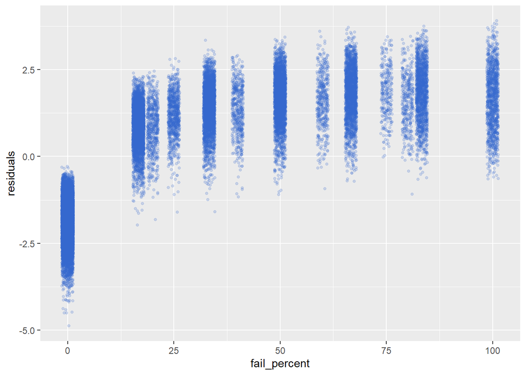

```r
# Plotting residuals vs fail_percent
data.frame(residuals = residuals(trans_model),
           fail_percent = school_data[train_indexes, "fail_percent"]) %>%
  ggplot(aes(x = fail_percent, y = residuals)) +
  geom_jitter(color = "#3366CC", alpha = .2, size = 1)
```

```r
# Testing residuals for normality
shapiro.test(sample(residuals(trans_model), 5000))
```

```
##
##  Shapiro-Wilk normality test
##
## data:  sample(residuals(trans_model), 5000)
## W = 0.92452, p-value < 2.2e-16
```

```r
# Calculating R square prediction using the testing data
mean_fail_percent <- mean(school_data$fail_percent_trans[-train_indexes])
predictions <- predict(trans_model, newdata = school_data[-train_indexes, ])
SST <- sum((school_data$fail_percent_trans[-train_indexes]
            - mean_fail_percent)^2)
SSRes <- sum((school_data$fail_percent_trans[-train_indexes] - predictions)^2)

R2Pred <- (SST - SSRes) / SST
cat("R square prediction:", R2Pred)
```

```
## R square prediction: 0.1560727
```

### 2.5.6 Evaluating New Model

The new model appears to perform worse than the original model. The R<sup>2</sup> value is lower, the prediction R<sup>2</sup> is lower, and the residuals did not become more uniformly distributed after the transformations. It is best to use a different model to complete this task, such as perhaps binomial logistic regression.

# 3 Conclusions and Recommendations

Analysis of the data has revealed many insights, and it has answered all of the business questions.

1. Attendance does have a significant correlation with school performance. Students that miss more class tend to receive worse marks.
2. The relationship is rather weak and not an accurate predictor of the mark a student will receive. Knowing the subject or name of a class a student takes might help improve predictability of `mark`, but attendance alone usually has a limited effect on student performance.
3. As little as 50 total absences or roughly 10 days of class time is enough to produce a statistically significant reduction in the percentage of classes that a student will pass. It is possible that even smaller differences in absences might be statistically significant.
4. 9th graders typically have the least absences, and 11th graders typically have the most. However, every grade tends to have many more absences in the second semester.
5. Does the effect of attendance on performance depend on a students grade level? (Need to answer this question in the future)
6. Students are most likely to be absent for 1st period, with each subsequent period becoming less likely. However, there is an increase in absences in 4th period.

There are various conditions that can decrease a student’s ability to perform well, and while it is not possible to guarantee a student’s success simply by improving these conditions, it is still possible to increase the likeliness that a student will. Firstly, since the number of absences a student has had the strongest correlation with a student’s performance, student attendance should be prioritized, particularly during certain situations where students are less likely to be present. For example, there could be morale boosting activities in the second semester to encourage students to attend even though they are less likely to. Since 11th graders are the worst offenders, they should be the ones that are most encouraged to attend. Marks are also affected by the period in which classes are taken, with a reduction in performance in periods 1, 5, and 6. Period 6 has the lowest scores on average, so measures should be taken to keep students interested and engaged during this final period.

## 3.1 Next Step

There are a few more questions that can be answered with this data set that weren’t discussed. For example, the marks and number of absences for students that changed schools could be explored. The effects of changing schools was largely ignored in the analysis, but it is possible that students that transfer in the middle of the school year tend to perform worse or better depending on which school they come from and go to. It’s also possible that transfer students may have more or less absences than other students. Similar relationships should be explored for students who do not return to school for a second semester.

Although some additional conclusions can be drawn from the data, it has Some clear limitations. Firstly, the student ids aren’t consistent each year, which makes it impossible to follow students’ progress over time. Secondly, it would have been helpful to know which classes students were taking in order to account for the difficulty of classes on the marks that students receive. Knowing what classes a student took would have greatly increased the predictability of a student’s mark, and controlling for the class a student took would have better allowed the model to find a clear relationship between `absences` and `mark`. Lastly, a numerical measure of the mark would have been appreciated to more easily sense the effect of `absences` on `mark` and to more accurately estimate the magnitude of the relationship. Also, using a numerical measure would have allowed for an average to be calculated among the marks a student received for each period, which would have been better to compare with `total_absences` than the `fail_percent` variable.